# BABS Neuropsych Summary

JLC

2023-07-02

# Brandeis Aging Brain Study (BABS) Neuropsych Battery: Descriptive Summary

```r
rm(list=ls())

# Packages
library(knitr); library(kableExtra); library(RColorBrewer); library(correlation); library(readxl); library(psych); library(ds4psy); library(tidyverse)

#Create data directories
NP.path<-"/Volumes/berry-lab/berry-lab/Brandeis_Aging_Brain_Study/BABS Data/Analysis/BABS NP MASTER.xlsx"
subj.path <-"/Volumes/berry-lab/berry-lab/Brandeis_Aging_Brain_Study/BABS Data/"

#Make data frames for neuropsych battery items from excel spreadsheet
BABS.NP.demo <- read_xlsx(NP.path, sheet = "Demographics")
BABS.NP.sess1 <- read_xlsx(NP.path, sheet = "Session 1")

#Make data frame for NIH toolbox data
sub.IDs <- c("BABS178","BABS182","BABS184","BABS186","BABS187","BABS188","BABS189","BABS190","BABS191","BABS192",
             "BABS193","BABS194","BABS195","BABS197","BABS198","BABS199","BABS200","BABS201","BABS203","BABS204",
             "BABS207","BABS208","BABS209","BABS210","BABS212","BABS213","BABS214","BABS215","BABS216","BABS217",
             "BABS218","BABS219","BABS220","BABS221","BABS222","BABS223","BABS224","BABS225","BABS226","BABS227",
             "BABS228","BABS229","BABS230","BABS231","BABS232","BABS232","BABS233","BABS234","BABS235","BABS236",
             "BABS237","BABS238","BABS239","BABS240","BABS241","BABS242","BABS243","BABS244","BABS245","BABS246",
             "BABS247","BABS248","BABS249","BABS251","BABS252","BABS253","BABS254","BABS255","BABS256","BABS257",
             "BABS258","BABS259","BABS260","BABS261","BABS262","BABS263","BABS264","BABS265","BABS267","BABS268",
             "BABS270","BABS271","BABS274","BABS275","BABS276","BABS277","BABS278","BABS280","BABS281","BABS282",
             "BABS283","BABS285","BABS287","BABS289","BABS212","BABS290","BABS291","BABS293","BABS294","BABS295",
             "BABS297","BABS298","BABS299","BABS300","BABS301","BABS302","BABS304","BABS305","BABS310")
NIH.toolbox.path <- data_frame()
for (sid in 1:length(sub.IDs)) {
      NIH.fname <- paste0(subj.path, sub.IDs[sid], "/Session_1/NIH_TOOLBOX/");
      file <- dir(NIH.fname, pattern = "*Structure Assessment Scores.csv");
      setwd(NIH.fname);
      file_data <- read_csv(file, col_types = "c");
NIH.toolbox.path <- bind_rows(NIH.toolbox.path, file_data);
}
#need to clean up variable entry of subject IDs
d.NIH <- NIH.toolbox.path %>%
  mutate(ID = parse_number(NIH.toolbox.path$PIN),
         BABS_ID = (paste0("BABS",ID)))
```

# Behavioral Measures

## General Cognitive Function

### MMSE

```r
#creating data frame with relevant variables
d.MMSE <- BABS.NP.sess1 %>% select(BABS_ID, `AGE AT SESSION`, MMSE) %>% distinct(BABS_ID, .keep_all = T) %>%
    mutate_at(vars(starts_with("MMSE")), as.numeric)
#counting the number of observations and summarizing mean & SD
MMSE.sum <- d.MMSE %>% describe() %>% select(-vars) %>% rownames_to_column(var = "Variable") %>%
  filter(Variable != "BABS_ID*") %>% filter(Variable != "AGE AT SESSION")

kable(MMSE.sum, col.names = c("Variable","N","Mean","SD","Median","Trimmed Mean","Median Abs. Deviation","Min","Max","Range","Skew","Kurtosis","SE"),
      caption = "MMSE Summary Table") %>% kable_styling()
```

MMSE Summary Table

| Variable | N | Mean | SD | Median | Trimmed Mean | Median Abs. Deviation | Min | Max | Range | Skew | Kurtosis | SE |
| --- | --- | --- | --- | --- | --- | --- | --- | --- | --- | --- | --- | --- |
| MMSE | 235 | 28.77021 | 1.590022 | 29 | 29.07407 | 1.4826 | 21 | 30 | 9 | -1.743826 | 3.427135 | 0.1037216 |

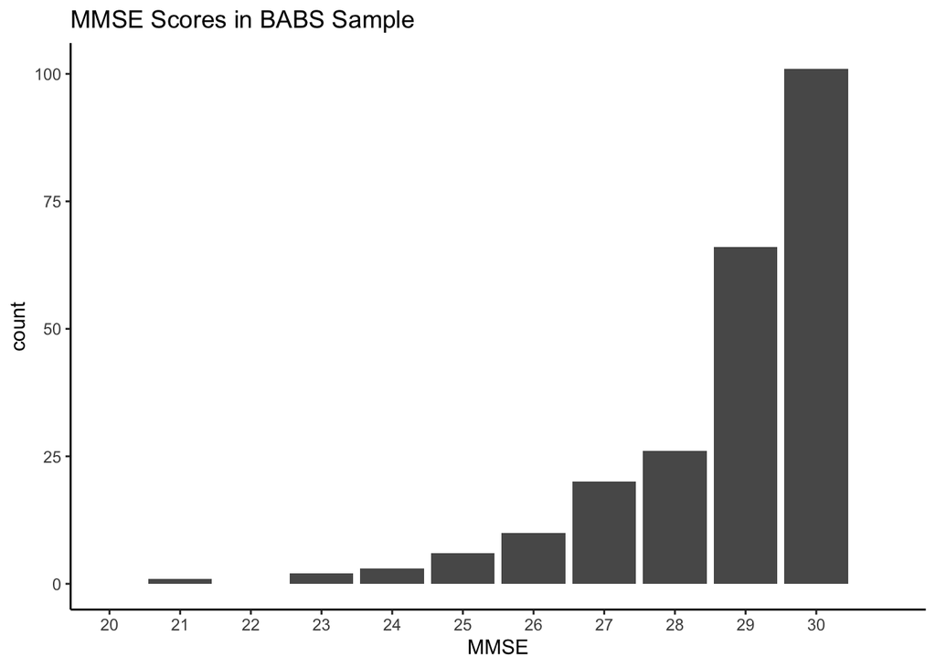

```r
#plotting distribution of scores
p.MMSE <- ggplot(d.MMSE, aes(MMSE)) +
  geom_bar() + scale_x_continuous(limits = c(20,31), breaks = seq(20,30,1)) +
  labs(title = "MMSE Scores in BABS Sample") +
  theme_classic()
p.MMSE
```

## Working Memory

### Digit Span

#### Forward

Note: BABS_259 has forward value of “8 or 7”; presently excluded for being non-numeric. Verify actual score.

```r
#creating data frame with relevant variables
d.DigSpan.F <- BABS.NP.sess1 %>% select(BABS_ID, `AGE AT SESSION`, DIGITSPAN_FORWARD) %>%
                                          distinct(BABS_ID, .keep_all = T) %>%
    mutate_at(vars(starts_with("DIGITSPAN")), as.numeric)
#counting the number of observations and summarizing mean & SD
DigSpan.F.sum <- d.DigSpan.F %>% describe() %>% select(-vars) %>% rownames_to_column(var = "Variable") %>%
  filter(Variable != "BABS_ID*") %>% filter(Variable != "AGE AT SESSION")

kable(DigSpan.F.sum, col.names = c("Variable","N","Mean","SD","Median","Trimmed Mean","Median Abs. Deviation","Min","Max","Range","Skew","Kurtosis","SE"),
      caption = "Forward Digit Span Summary Table") %>% kable_styling()
```

Forward Digit Span Summary Table

| Variable | N | Mean | SD | Median | Trimmed Mean | Median Abs. Deviation | Min | Max | Range | Skew | Kurtosis | SE |
| --- | --- | --- | --- | --- | --- | --- | --- | --- | --- | --- | --- | --- |
| DIGITSPAN_FORWARD | 231 | 9.012987 | 2.403766 | 9 | 9.016216 | 2.9652 | 2 | 14 | 12 | -0.0993574 | -0.6395699 | 0.1581562 |

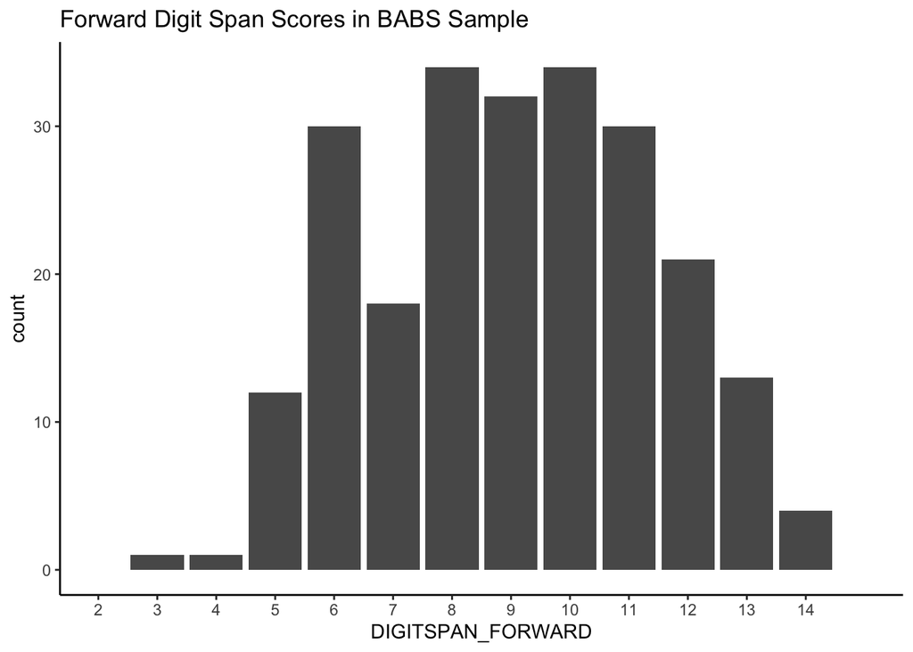

```r
#plotting distribution of scores
p.DigSpan.F <- ggplot(d.DigSpan.F, aes(DIGITSPAN_FORWARD)) +
  geom_bar() + scale_x_continuous(limits = c(2,15), breaks = seq(2,14,1)) +
  labs(title = "Forward Digit Span Scores in BABS Sample") +
  theme_classic()
p.DigSpan.F
```

#### Backward

```r
#creating data frame with relevant variables
d.DigSpan.B <- BABS.NP.sess1 %>% select(BABS_ID, `AGE AT SESSION`, DIGITSPAN_BACKWARD) %>%
                                          distinct(BABS_ID, .keep_all = T) %>%
  mutate_at(vars(starts_with("DIGITSPAN")), as.numeric)
#counting the number of observations and summarizing mean & SD
DigSpan.B.sum <- d.DigSpan.B %>% describe() %>% select(-vars) %>% rownames_to_column(var = "Variable") %>%
  filter(Variable != "BABS_ID*") %>% filter(Variable != "AGE AT SESSION")

kable(DigSpan.B.sum, col.names = c("Variable","N","Mean","SD","Median","Trimmed Mean","Median Abs. Deviation","Min","Max","Range","Skew","Kurtosis","SE"),
      caption = "Backward Digit Span Summary Table") %>% kable_styling()
```

Backward Digit Span Summary Table

| Variable | N | Mean | SD | Median | Trimmed Mean | Median Abs. Deviation | Min | Max | Range | Skew | Kurtosis | SE |
| --- | --- | --- | --- | --- | --- | --- | --- | --- | --- | --- | --- | --- |
| DIGITSPAN_BACKWARD | 233 | 7.76824 | 4.816228 | 7 | 7.331551 | 1.4826 | 3 | 71 | 68 | 9.791732 | 124.798 | 0.3155216 |

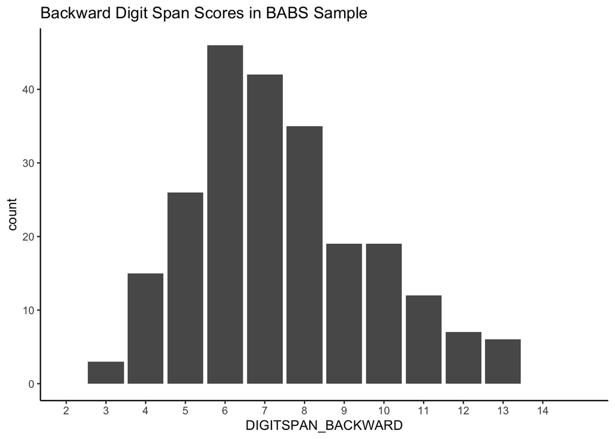

```r
#plotting distribution of scores
p.DigSpan.B <- ggplot(d.DigSpan.B, aes(DIGITSPAN_BACKWARD)) +
  geom_bar() + scale_x_continuous(limits = c(2,15), breaks = seq(2,14,1)) +
  labs(title = "Backward Digit Span Scores in BABS Sample") +
  theme_classic()
p.DigSpan.B
```

### Keep Track Task

Note: Will need to verify what happened here; early Ss have 1 (not 4) category, but later have 4 (not 1). Inconsistent number of observations across conditions.

```r
#creating data frame with relevant variables
d.KeepTrack <- BABS.NP.sess1 %>% select(BABS_ID, `AGE AT SESSION`, starts_with("KEEP"), THREECATEGORIES_TOTAL) %>%
                                          distinct(BABS_ID, .keep_all = T) %>%
  mutate_at(vars(ends_with("TOTAL")), as.numeric)
#counting the number of observations and summarizing mean & SD
KeepTrack.sum <- d.KeepTrack %>% describe() %>% select(-vars) %>% rownames_to_column(var = "Variable") %>%
  filter(Variable != "BABS_ID*") %>% filter(Variable != "AGE AT SESSION")

kable(KeepTrack.sum, col.names = c("Variable","N","Mean","SD","Median","Trimmed Mean","Median Abs. Deviation","Min","Max","Range","Skew","Kurtosis","SE"),
      caption = "Keep Track Summary Table") %>% kable_styling()
```

Keep Track Summary Table

| Variable | N | Mean | SD | Median | Trimmed Mean | Median Abs. Deviation | Min | Max | Range | Skew | Kurtosis | SE |
| --- | --- | --- | --- | --- | --- | --- | --- | --- | --- | --- | --- | --- |
| KEEPTRACK_DIFFICULTY_LEVEL* | 160 | 2.12500 | 0.3677229 | 2.00 | 2.046875 | 0.0000 | 1.000000 | 3 | 2.00000 | 1.4612044 | 2.5145164 | 0.029071 |
| KEEPTRACK_ONECATEGORY_TOTAL | 22 | 97.72727 | 7.3561236 | 100.00 | 100.000000 | 0.0000 | 75.000000 | 100 | 25.00000 | -2.6542231 | 5.2915289 | 1.568331 |
| KEEPTRACK_TWOCATEGORIES_TOTAL | 160 | 88.20312 | 16.8375793 | 100.00 | 91.503906 | 0.0000 | 12.500000 | 100 | 87.50000 | -2.0041373 | 4.9352907 | 1.331128 |
| KEEPTRACK_FOURCATEGORIES_TOTAL | 137 | 59.03285 | 18.7181057 | 56.25 | 59.121622 | 18.5325 | 12.500000 | 100 | 87.50000 | -0.0120957 | -0.5294273 | 1.599196 |
| THREECATEGORIES_TOTAL | 159 | 69.75891 | 21.6770800 | 75.00 | 71.124031 | 24.7100 | 8.333333 | 100 | 91.66667 | -0.5571547 | -0.1715102 | 1.719104 |

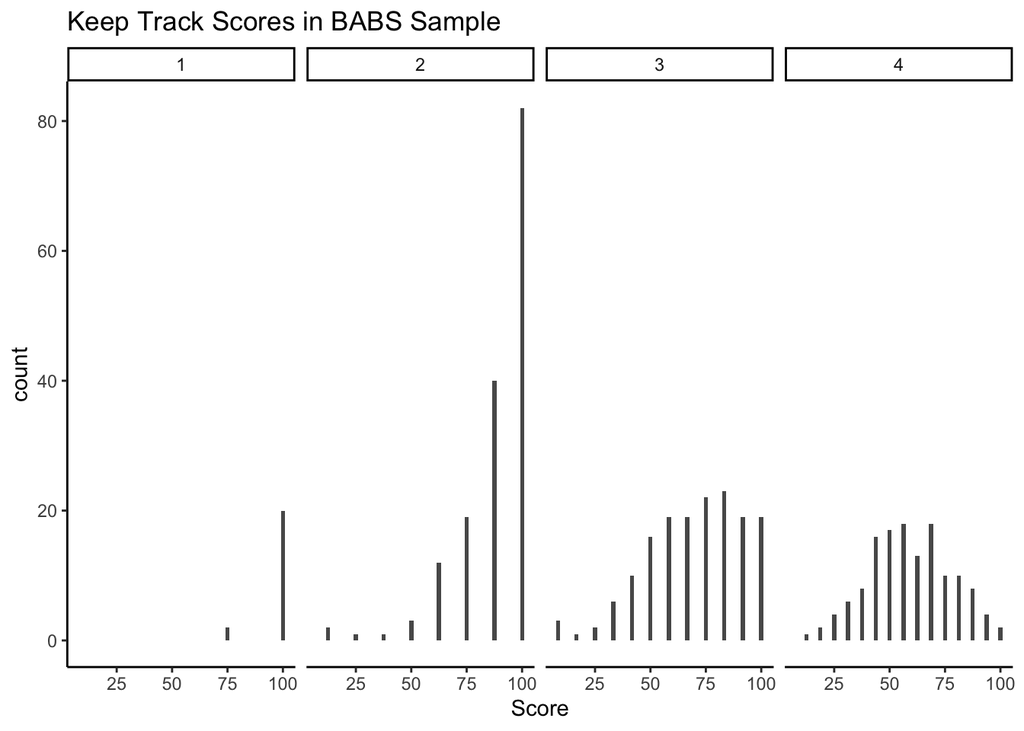

```r
#creating long data frame
d.KeepTrack.long <- d.KeepTrack %>%
  pivot_longer(names_to = "Level", values_to = "Score", -c(BABS_ID, `AGE AT SESSION`, KEEPTRACK_DIFFICULTY_LEVEL))
d.KeepTrack.long$Level <- factor(d.KeepTrack.long$Level, levels = c("KEEPTRACK_ONECATEGORY_TOTAL","KEEPTRACK_TWOCATEGORIES_TOTAL","THREECATEGORIES_TOTAL", "KEEPTRACK_FOURCATEGORIES_TOTAL"), labels = c(1,2,3,4))
#plotting distribution of scores
p.KeepTrack <- ggplot(d.KeepTrack.long, aes(Score)) +
  geom_bar() +
  labs(title = "Keep Track Scores in BABS Sample") +
  theme_classic() + facet_grid(.~Level)
p.KeepTrack
```

### Spatial N-Back

```r
#creating data frame with relevant variables
d.NBack <- BABS.NP.sess1 %>% select(BABS_ID, `AGE AT SESSION`, starts_with("NBACK")) %>%
                                          distinct(BABS_ID, .keep_all = T) %>%
    mutate_at(vars(ends_with("BACK")), as.numeric)
#counting the number of observations and summarizing mean & SD
Nback.sum <- d.NBack %>% describe() %>% select(-vars) %>% rownames_to_column(var = "Variable") %>%
  filter(Variable != "BABS_ID*") %>% filter(Variable != "AGE AT SESSION")

kable(Nback.sum, col.names = c("Variable","N","Mean","SD","Median","Trimmed Mean","Median Abs. Deviation","Min","Max","Range","Skew","Kurtosis","SE"),
      caption = "Spatial N-Back Summary Table") %>% kable_styling()
```

Spatial N-Back Summary Table

| Variable | N | Mean | SD | Median | Trimmed Mean | Median Abs. Deviation | Min | Max | Range | Skew | Kurtosis | SE |
| --- | --- | --- | --- | --- | --- | --- | --- | --- | --- | --- | --- | --- |
| NBACK_VERSION* | 158 | 1.968354 | 0.8093474 | 2.00000 | 1.960938 | 1.482600 | 1.00000 | 3 | 2.00000 | 0.0569268 | -1.4809250 | 0.0643882 |
| NBACK_DIFFICULTY_LEVEL* | 157 | 1.140127 | 0.3482299 | 1.00000 | 1.055118 | 0.000000 | 1.00000 | 2 | 1.00000 | 2.0537030 | 2.2320342 | 0.0277918 |
| NBACK_ONEBACK | 158 | 84.124473 | 16.7610320 | 93.05556 | 86.653646 | 8.236667 | 31.94444 | 100 | 68.05556 | -1.0701076 | 0.2910857 | 1.3334361 |
| NBACK_TWOBACK | 157 | 84.005662 | 16.9342868 | 90.27778 | 87.270341 | 8.236667 | 22.22222 | 100 | 77.77778 | -1.9272787 | 3.5314447 | 1.3515032 |

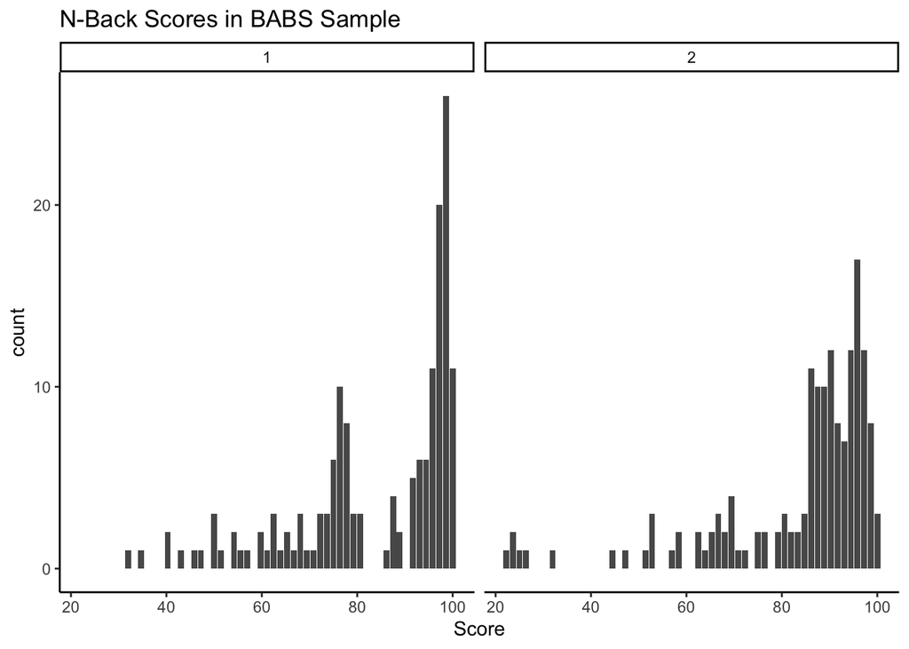

```r
#creating long data frame
d.Nback.long <- d.NBack %>%
  pivot_longer(names_to = "Level", values_to = "Score", -c(BABS_ID, `AGE AT SESSION`, NBACK_VERSION, NBACK_DIFFICULTY_LEVEL))
d.Nback.long$Level <- factor(d.Nback.long$Level, levels = c("NBACK_ONEBACK","NBACK_TWOBACK"),
                                 labels = c(1,2))
#plotting distribution of scores
p.Nback <- ggplot(d.Nback.long, aes(Score)) +
  geom_bar() +
  labs(title = "N-Back Scores in BABS Sample") +
  theme_classic() + facet_grid(.~Level)
p.Nback
```

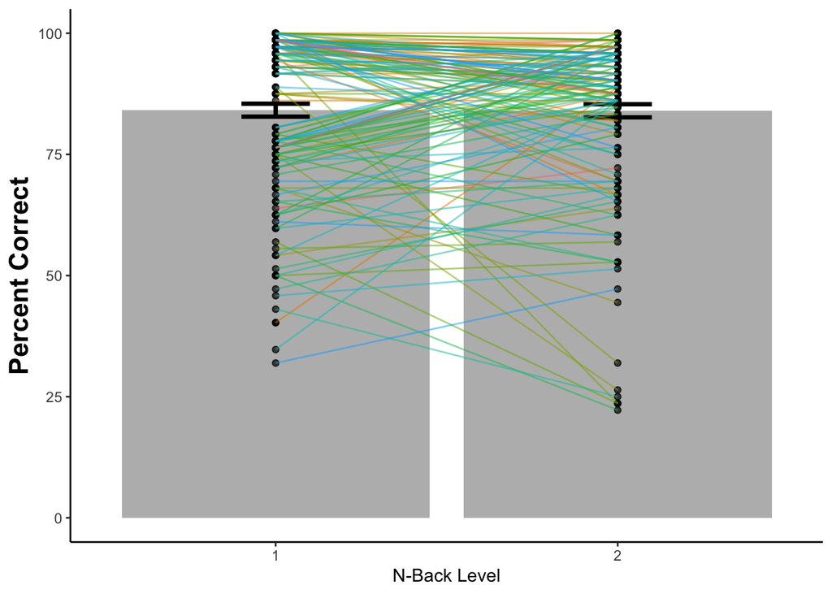

```r
#adding a new variable for ease of plotting
Nback.sum$Level <- factor(Nback.sum$Variable, levels = c("NBACK_ONEBACK", "NBACK_TWOBACK"), labels = c(1,2))
d.Nback.long$mean <- d.Nback.long$Score
fig.Nback.lines <- ggplot(Nback.sum %>% filter(Level == 1 | Level == 2), aes(x=Level, y=mean)) +
  theme(plot.title = element_text(hjust = 0.5), panel.grid.major = element_blank(), panel.grid.minor = element_blank(), panel.background = element_blank(), axis.line = element_line(colour = "black"), axis.title.y = element_text(face="bold", size=16),legend.title = element_text(face="bold", size=16)) +
  geom_bar(stat="identity", position=position_dodge(), alpha=.45, size=1.5) +
  geom_errorbar(position=position_dodge(width=0.9), aes(ymin=mean-se, ymax=mean+se), width=.2, size=1.25) +
  geom_point(data = d.Nback.long, aes(x=Level, y=mean),
             stat="identity", alpha=0.7) +
  geom_line(data = d.Nback.long, aes(x=Level, y=mean, group=BABS_ID, colour = factor(BABS_ID)), alpha = .5) +
  xlab("N-Back Level") + ylab("Percent Correct")
fig.Nback <- fig.Nback.lines + guides(colour=FALSE)
fig.Nback
```

## Inhibition

### Stroop (Paper version)

Note: Inconsistent number of participants across conditions.

```r
#creating data frame with relevant variables
d.Stroop.paper <- BABS.NP.sess1 %>% select(BABS_ID, `AGE AT SESSION`, starts_with("STROOP")) %>%
  select(-STROOP_INCONG_MINUS_CONG_CORR) %>% distinct(BABS_ID, .keep_all = T) %>%
  mutate_at(vars(starts_with("STROOP")), as.numeric)

Stroop.paper.sum <- d.Stroop.paper %>% describe() %>% select(-vars) %>% rownames_to_column(var = "Variable") %>%
  filter(Variable != "BABS_ID*") %>% filter(Variable != "AGE AT SESSION")

kable(Stroop.paper.sum, col.names = c("Variable","N","Mean","SD","Median","Trimmed Mean","Median Abs. Deviation","Min","Max","Range","Skew","Kurtosis","SE"),
      caption = "Stroop Paper Summary Table") %>% kable_styling()
```

Stroop Paper Summary Table

| Variable | N | Mean | SD | Median | Trimmed Mean | Median Abs. Deviation | Min | Max | Range | Skew | Kurtosis | SE |
| --- | --- | --- | --- | --- | --- | --- | --- | --- | --- | --- | --- | --- |
| STROOP_WORD_CORRECT | 62 | 86.2258065 | 17.1716688 | 86.5 | 86.0600000 | 15.5673 | 48 | 127 | 79 | 0.0914627 | -0.3061983 | 2.1808041 |
| STROOP_WORD_INCORRECT | 62 | 0.1612903 | 0.4126503 | 0.0 | 0.0600000 | 0.0000 | 0 | 2 | 2 | 2.4592741 | 5.5801186 | 0.0524066 |
| STROOP_COLOR_CORRECT | 63 | 61.6984127 | 9.9102992 | 61.0 | 61.9607843 | 8.8956 | 38 | 84 | 46 | -0.2242331 | -0.0705104 | 1.2485803 |
| STROOP_COLOR_INCORRECT | 63 | 0.5555556 | 0.7987445 | 0.0 | 0.4313725 | 0.0000 | 0 | 3 | 3 | 1.1298025 | 0.0863561 | 0.1006324 |
| STROOP_COLORWORD_CORRECT | 63 | 36.9206349 | 9.6474994 | 38.0 | 36.7254902 | 7.4130 | 17 | 70 | 53 | 0.4489847 | 1.2500135 | 1.2154707 |
| STROOP_COLORWORD_INCORRECT | 63 | 0.8253968 | 1.6708090 | 0.0 | 0.4313725 | 0.0000 | 0 | 10 | 10 | 3.2738011 | 13.0565474 | 0.2105021 |

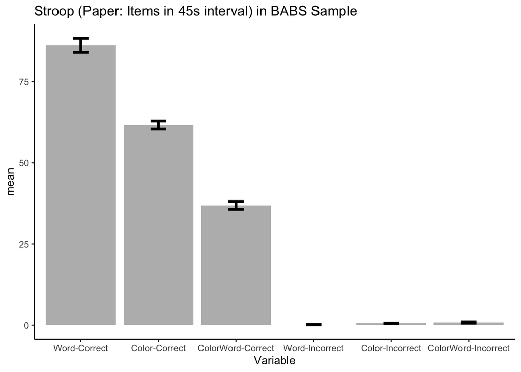

```r
#plotting summary of scores across condition
##changing variable name for ease of plotting
Stroop.paper.sum$Variable <- factor(Stroop.paper.sum$Variable, levels = c("STROOP_WORD_CORRECT", "STROOP_COLOR_CORRECT", "STROOP_COLORWORD_CORRECT", "STROOP_WORD_INCORRECT", "STROOP_COLOR_INCORRECT", "STROOP_COLORWORD_INCORRECT"), labels = c("Word-Correct", "Color-Correct", "ColorWord-Correct", "Word-Incorrect","Color-Incorrect","ColorWord-Incorrect"))
p.Stroop.paper <- ggplot(Stroop.paper.sum, aes(x=Variable, y=mean)) +
  geom_bar(stat="identity", position=position_dodge(), alpha=.45, size=1.5) +
  geom_errorbar(position=position_dodge(width=0.9), aes(ymin=mean-se, ymax=mean+se), width=.2, size=1.25) +
  labs(title = "Stroop (Paper: Items in 45s interval) in BABS Sample") +
  theme_classic()
p.Stroop.paper
```

### Stroop (Computer version)

```r
#creating data frame with relevant variables
d.Stroop.comp <- BABS.NP.sess1 %>% select(BABS_ID, `AGE AT SESSION`, ends_with("CORR")) %>%
 distinct(BABS_ID, .keep_all = T) %>%
  mutate_at(vars(starts_with("STROOP")), as.numeric)

Stroop.comp.sum <- d.Stroop.comp %>% describe() %>% select(-vars) %>% rownames_to_column(var = "Variable") %>%
  filter(Variable != "BABS_ID*") %>% filter(Variable != "AGE AT SESSION")

kable(Stroop.comp.sum, col.names = c("Variable","N","Mean","SD","Median","Trimmed Mean","Median Abs. Deviation","Min","Max","Range","Skew","Kurtosis","SE"),
      caption = "Stroop (Stroop Effect in ms) Summary Table") %>% kable_styling()
```

Stroop (Stroop Effect in ms) Summary Table

| Variable | N | Mean | SD | Median | Trimmed Mean | Median Abs. Deviation | Min | Max | Range | Skew | Kurtosis | SE |
| --- | --- | --- | --- | --- | --- | --- | --- | --- | --- | --- | --- | --- |
| STROOP_INCONG_MINUS_CONG_CORR | 162 | 343.1403 | 134.1523 | 331.1932 | 334.7677 | 117.8873 | 25.51612 | 741.2341 | 715.718 | 0.4830102 | 0.1872331 | 10.54 |

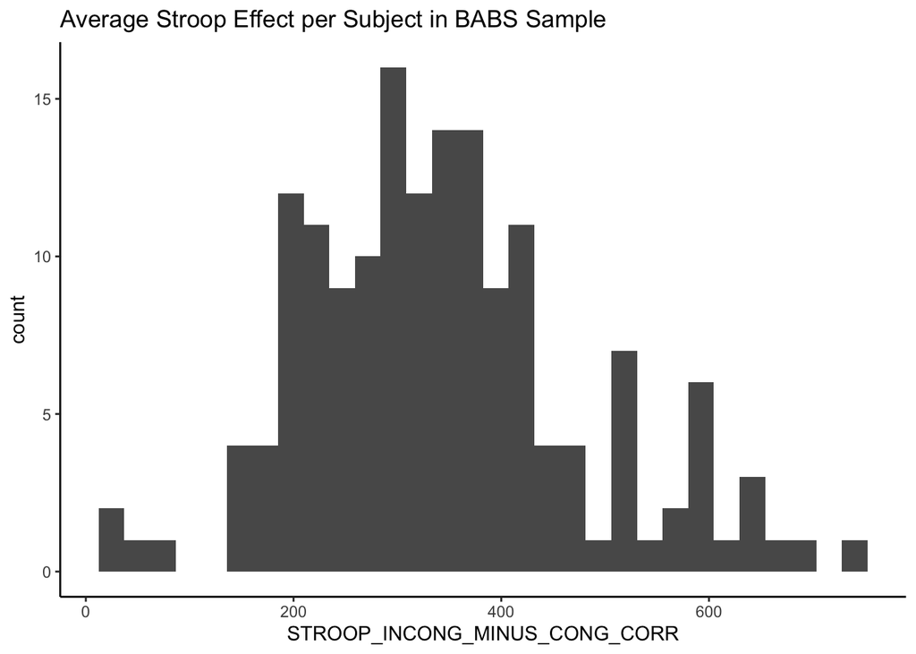

```r
#plotting summary of scores across condition
p.Stroop.comp <- ggplot(d.Stroop.comp, aes(STROOP_INCONG_MINUS_CONG_CORR)) +
  geom_histogram() +
  labs(title = "Average Stroop Effect per Subject in BABS Sample") +
  theme_classic()
p.Stroop.comp
```

### NIH Toolbox: Flanker

Note: Raw scores might not be informative since almost everyone has this same raw score.

```r
#creating data frame with relevant variables
d.Flanker <- d.NIH %>% select(BABS_ID, TestName, Key, Value) %>%
 filter(TestName == "Flank_2") %>% filter(Key == "RawScore") %>%
  mutate_at(vars(starts_with("Value")), as.numeric)

Flanker.sum <- d.Flanker %>% describe() %>% select(-vars) %>% rownames_to_column(var = "Variable") %>%
  filter(Variable != "BABS_ID*") %>% filter(Variable != "TestName*") %>% filter(Variable != "Key*")

kable(Flanker.sum, col.names = c("Variable","N","Mean","SD","Median","Trimmed Mean","Median Abs. Deviation","Min","Max","Range","Skew","Kurtosis","SE"),
      caption = "NIH Toolbox Flanker (Raw Score) Summary Table") %>% kable_styling()
```

NIH Toolbox Flanker (Raw Score) Summary Table

| Variable | N | Mean | SD | Median | Trimmed Mean | Median Abs. Deviation | Min | Max | Range | Skew | Kurtosis | SE |
| --- | --- | --- | --- | --- | --- | --- | --- | --- | --- | --- | --- | --- |
| Value | 107 | 19.94393 | 0.2688822 | 20 | 20 | 0 | 18 | 20 | 2 | -5.140275 | 28.21165 | 0.0259938 |

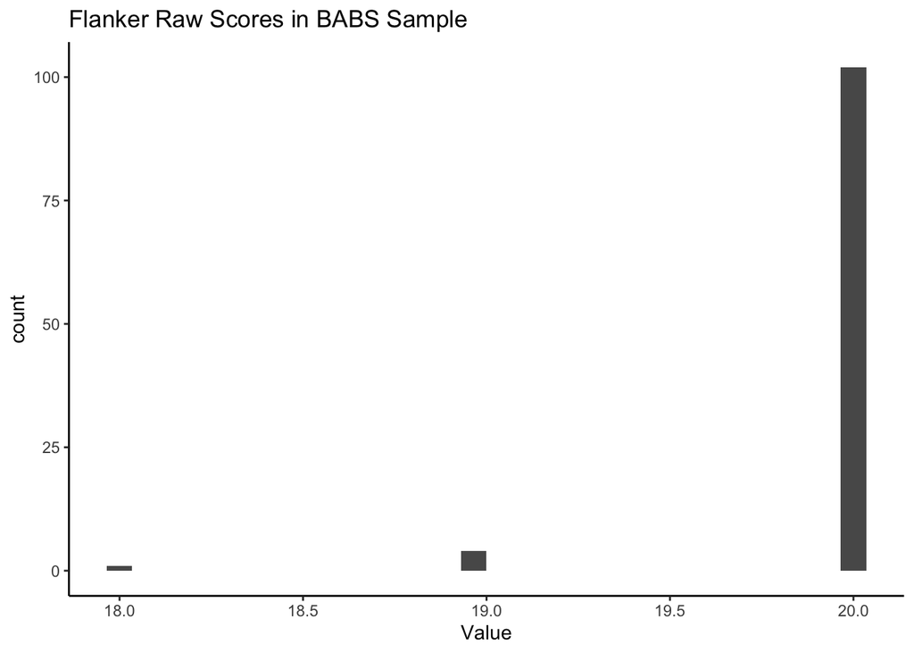

```r
#plotting summary of scores across condition
p.Flanker <- ggplot(d.Flanker, aes(Value)) +
  geom_histogram() +
  labs(title = "Flanker Raw Scores in BABS Sample") +
  theme_classic()
p.Flanker
```

## Cognitive Flexibility

### NIH Toolbox: Dimensional Change Card Sort (DCCS)

```r
#creating data frame with relevant variables
d.DCCS<- d.NIH %>% select(BABS_ID, TestName, Key, Value) %>%
 filter(TestName == "DCCS_2") %>% filter(Key == "RawScore") %>%
  mutate_at(vars(starts_with("Value")), as.numeric)

DCCS.sum <- d.DCCS %>% describe() %>% select(-vars) %>% rownames_to_column(var = "Variable") %>%
  filter(Variable != "BABS_ID*") %>% filter(Variable != "TestName*") %>% filter(Variable != "Key*")

kable(DCCS.sum, col.names = c("Variable","N","Mean","SD","Median","Trimmed Mean","Median Abs. Deviation","Min","Max","Range","Skew","Kurtosis","SE"),
      caption = "NIH Toolbox DCCS (Raw Score) Summary Table") %>% kable_styling()
```

NIH Toolbox DCCS (Raw Score) Summary Table

| Variable | N | Mean | SD | Median | Trimmed Mean | Median Abs. Deviation | Min | Max | Range | Skew | Kurtosis | SE |
| --- | --- | --- | --- | --- | --- | --- | --- | --- | --- | --- | --- | --- |
| Value | 108 | 29.40741 | 0.9475698 | 30 | 29.59091 | 0 | 25 | 30 | 5 | -1.988591 | 4.593008 | 0.0911799 |

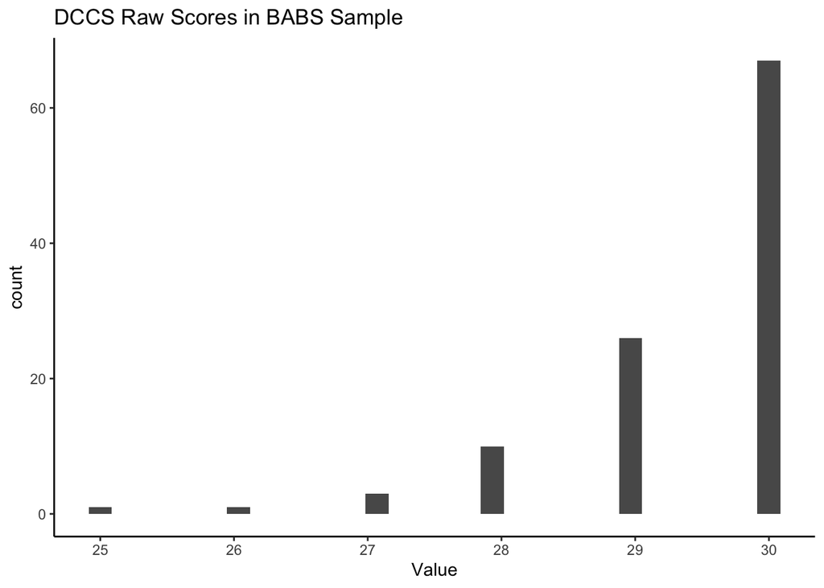

```r
#plotting summary of scores across condition
p.DCCS <- ggplot(d.DCCS, aes(Value)) +
  geom_histogram() +
  labs(title = "DCCS Raw Scores in BABS Sample") +
  theme_classic()
p.DCCS
```

### Cognitive Reflection Test

Note: Scores can only range from 0-3; BABS_031 has a score of -3.

```r
d.CRT <- BABS.NP.sess1 %>% select(BABS_ID, `AGE AT SESSION`, starts_with("CRT")) %>%
                                          distinct(BABS_ID, .keep_all = T) %>%
  mutate_at(vars(starts_with("CRT")), as.numeric)
#counting the number of observations and summarizing mean & SD
CRT.sum <- d.CRT %>% describe() %>% select(-vars) %>% rownames_to_column(var = "Variable") %>%
  filter(Variable != "BABS_ID*") %>% filter(Variable != "AGE AT SESSION")

kable(CRT.sum, col.names = c("Variable","N","Mean","SD","Median","Trimmed Mean","Median Abs. Deviation","Min","Max","Range","Skew","Kurtosis","SE"),
      caption = "Cognitive Relfection Summary Table") %>% kable_styling()
```

Cognitive Relfection Summary Table

| Variable | N | Mean | SD | Median | Trimmed Mean | Median Abs. Deviation | Min | Max | Range | Skew | Kurtosis | SE |
| --- | --- | --- | --- | --- | --- | --- | --- | --- | --- | --- | --- | --- |
| CRT | 188 | 1.319149 | 1.238533 | 1 | 1.296053 | 1.4826 | -3 | 3 | 6 | -0.0301141 | -0.914706 | 0.0903293 |

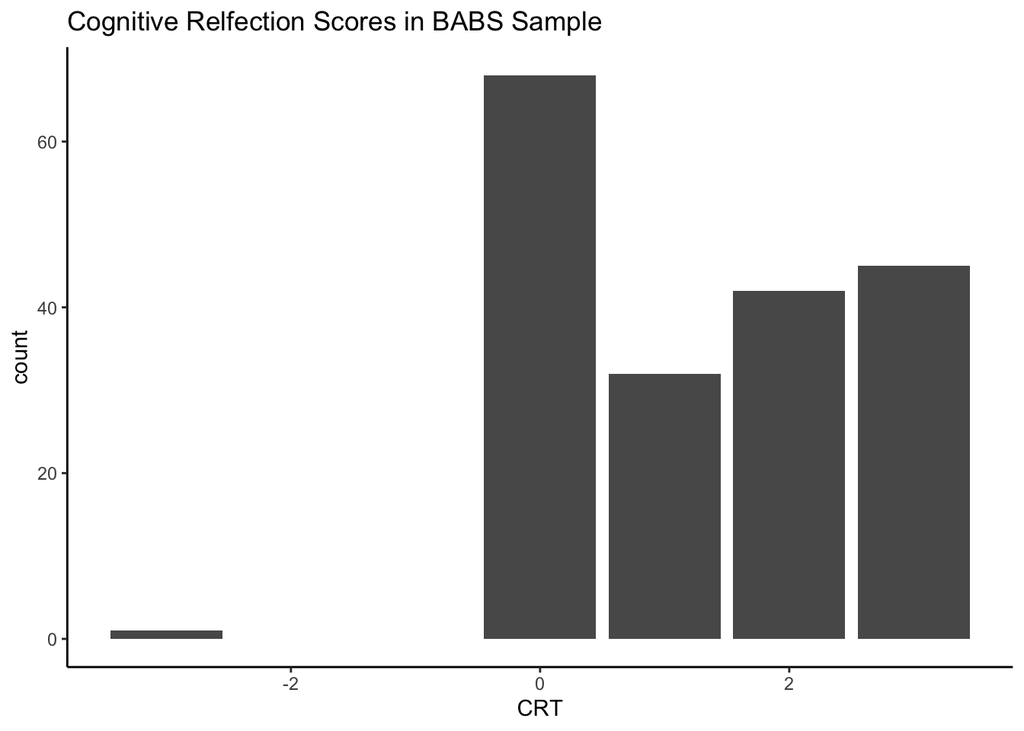

```r
#plotting distribution of scores
p.CRT <- ggplot(d.CRT, aes(CRT)) +
  geom_bar() +
  labs(title = "Cognitive Relfection Scores in BABS Sample") +
  theme_classic()
p.CRT
```

## Learning and Memory

### California Verbal Learning Test (CVLT)

Note: Should look into _REPETITIONS scores; ranges 0-49, but the mean is ~4.

```r
d.CVLT <- BABS.NP.sess1 %>% select(BABS_ID, `AGE AT SESSION`, starts_with("CVLT")) %>%
                                          distinct(BABS_ID, .keep_all = T) %>%
  mutate_at(vars(starts_with("CVLT")), as.numeric)
#counting the number of observations and summarizing mean & SD
CVLT.sum <- d.CVLT %>% describe() %>% select(-vars) %>% rownames_to_column(var = "Variable") %>%
  filter(Variable != "BABS_ID*") %>% filter(Variable != "AGE AT SESSION")

kable(CVLT.sum, col.names = c("Variable","N","Mean","SD","Median","Trimmed Mean","Median Abs. Deviation","Min","Max","Range","Skew","Kurtosis","SE"),
      caption = "CVLT Summary Table") %>% kable_styling()
```

CVLT Summary Table

| Variable | N | Mean | SD | Median | Trimmed Mean | Median Abs. Deviation | Min | Max | Range | Skew | Kurtosis | SE |
| --- | --- | --- | --- | --- | --- | --- | --- | --- | --- | --- | --- | --- |
| CVLT_LISTA_FR_TRIAL1 | 234 | 6.581197 | 1.972947 | 6 | 6.4680851 | 1.4826 | 2 | 14 | 12 | 0.5924678 | 0.4742444 | 0.1289756 |
| CVLT_LISTA_FR_TRIAL2 | 234 | 9.559829 | 2.567260 | 9 | 9.5000000 | 2.9652 | 4 | 16 | 12 | 0.1972079 | -0.5387642 | 0.1678271 |
| CVLT_LISTA_FR_TRIAL3 | 234 | 11.025641 | 2.680278 | 11 | 11.0638298 | 2.9652 | 4 | 16 | 12 | -0.1404380 | -0.4667563 | 0.1752152 |
| CVLT_LISTA_FR_TRIAL4 | 234 | 11.850427 | 2.582348 | 12 | 11.9840426 | 2.9652 | 1 | 16 | 15 | -0.5293390 | 0.3075996 | 0.1688133 |
| CVLT_LISTA_FR_TRIAL5 | 234 | 12.371795 | 2.583086 | 13 | 12.5691489 | 2.9652 | 5 | 16 | 11 | -0.6375000 | -0.0775912 | 0.1688616 |
| CVLT_LISTB_FR_CORRECT | 234 | 5.435897 | 2.120347 | 5 | 5.2553191 | 1.4826 | 1 | 12 | 11 | 0.7785799 | 0.7965809 | 0.1386114 |
| CVLT_SD_FR_CORRECT | 234 | 10.910256 | 3.357852 | 11 | 11.1170213 | 2.9652 | 0 | 16 | 16 | -0.5862218 | 0.0355232 | 0.2195097 |
| CVLT_SD_CR_CORRECT | 234 | 12.149573 | 2.783894 | 13 | 12.3670213 | 2.9652 | 3 | 16 | 13 | -0.6861386 | 0.0680501 | 0.1819888 |
| CVLT_LD_FR_CORRECT | 234 | 11.606838 | 3.354472 | 12 | 11.9042553 | 2.9652 | 2 | 16 | 14 | -0.6898722 | -0.1090866 | 0.2192887 |
| CVLT_LD_CR_CORRECT | 234 | 12.371795 | 2.885998 | 13 | 12.6808511 | 2.9652 | 3 | 16 | 13 | -0.8525876 | 0.4442626 | 0.1886636 |
| CVLT_FR_INTRUSTIONS | 234 | 1.910256 | 2.975663 | 1 | 1.2925532 | 1.4826 | 0 | 22 | 22 | 3.1200502 | 13.4724746 | 0.1945252 |
| CVLT_CR_INTRUSTIONS | 234 | 1.200855 | 2.097986 | 0 | 0.7553191 | 0.0000 | 0 | 16 | 16 | 3.4029006 | 16.5355194 | 0.1371496 |
| CVLT_TOTAL_REPETITIONS | 234 | 4.294872 | 5.084966 | 3 | 3.4946809 | 2.9652 | 0 | 49 | 49 | 3.7094556 | 25.2716214 | 0.3324147 |
| CVLT_LD_RECOG_HITS | 233 | 14.708154 | 1.600316 | 15 | 14.9946524 | 1.4826 | 8 | 16 | 8 | -1.7886110 | 3.9773679 | 0.1048402 |
| CVLT_LD_RECOG_FA | 234 | 1.961539 | 3.116241 | 1 | 1.2978723 | 1.4826 | 0 | 23 | 23 | 3.2757112 | 14.9532479 | 0.2037151 |

### Face-Name Associative Memory Examination (FNAME)

```r
d.FME <- BABS.NP.sess1 %>% select(BABS_ID, `AGE AT SESSION`, starts_with("FME")) %>%
                                          distinct(BABS_ID, .keep_all = T) %>%
  mutate_at(vars(starts_with("FME")), as.numeric)
#counting the number of observations and summarizing mean & SD
FME.sum <- d.FME %>% describe() %>% select(-vars) %>% rownames_to_column(var = "Variable") %>%
  filter(Variable != "BABS_ID*") %>% filter(Variable != "AGE AT SESSION")

kable(FME.sum, col.names = c("Variable","N","Mean","SD","Median","Trimmed Mean","Median Abs. Deviation","Min","Max","Range","Skew","Kurtosis","SE"),
      caption = "Face-Name Associative Memory Summary Table") %>% kable_styling()
```

Face-Name Associative Memory Summary Table

| Variable | N | Mean | SD | Median | Trimmed Mean | Median Abs. Deviation | Min | Max | Range | Skew | Kurtosis | SE |
| --- | --- | --- | --- | --- | --- | --- | --- | --- | --- | --- | --- | --- |
| FME_ILN | 217 | 5.930876 | 3.676731 | 5 | 5.680000 | 4.4478 | 0 | 14 | 14 | 0.5031323 | -0.7003699 | 0.2495927 |
| FME_ILO | 217 | 8.801843 | 3.343373 | 9 | 8.851429 | 2.9652 | 0 | 16 | 16 | -0.1277425 | -0.5122885 | 0.2269630 |
| FME_CRN | 217 | 3.018433 | 3.750263 | 1 | 2.348571 | 1.4826 | 0 | 15 | 15 | 1.2830945 | 0.6754870 | 0.2545844 |
| FME_CRO | 217 | 5.663595 | 4.658943 | 6 | 5.382857 | 5.9304 | 0 | 16 | 16 | 0.1795871 | -1.1337371 | 0.3162697 |
| FME_CRN30 | 217 | 3.018433 | 3.720518 | 2 | 2.348571 | 2.9652 | 0 | 15 | 15 | 1.2864357 | 0.7655591 | 0.2525652 |
| FME_CRO30 | 217 | 5.456221 | 4.584512 | 6 | 5.154286 | 5.9304 | 0 | 16 | 16 | 0.2500750 | -1.1007490 | 0.3112170 |
| FME_FRN | 217 | 4.792627 | 2.750142 | 5 | 4.628571 | 2.9652 | 0 | 13 | 13 | 0.4894681 | -0.1148482 | 0.1866918 |
| FME_FRO | 217 | 7.695852 | 2.335243 | 8 | 7.651429 | 1.4826 | 0 | 15 | 15 | 0.1675045 | 0.5035043 | 0.1585267 |
| FME_FRN30 | 217 | 5.188940 | 2.980844 | 5 | 4.982857 | 2.9652 | 0 | 14 | 14 | 0.6329145 | 0.0428074 | 0.2023529 |
| FME_FRO30 | 217 | 7.695852 | 2.615770 | 8 | 7.668571 | 2.9652 | 2 | 15 | 13 | 0.1912111 | -0.2210971 | 0.1775700 |

## Visuospatial

### Visual Reproduction

Note: Scores for each sub-scale range from 0-104. BABS055 has a VR2 score = 119; verify actual score.

```r
d.WMS <- BABS.NP.sess1 %>% select(BABS_ID, `AGE AT SESSION`, starts_with("WMS")) %>%
                                          distinct(BABS_ID, .keep_all = T) %>%
  mutate_at(vars(starts_with("WMS")), as.numeric)
#counting the number of observations and summarizing mean & SD
WMS.sum <- d.WMS %>% describe() %>% select(-vars) %>% rownames_to_column(var = "Variable") %>%
  filter(Variable != "BABS_ID*") %>% filter(Variable != "AGE AT SESSION")

kable(WMS.sum, col.names = c("Variable","N","Mean","SD","Median","Trimmed Mean","Median Abs. Deviation","Min","Max","Range","Skew","Kurtosis","SE"),
      caption = "Visual Reproduction Summary Table") %>% kable_styling()
```

Visual Reproduction Summary Table

| Variable | N | Mean | SD | Median | Trimmed Mean | Median Abs. Deviation | Min | Max | Range | Skew | Kurtosis | SE |
| --- | --- | --- | --- | --- | --- | --- | --- | --- | --- | --- | --- | --- |
| WMS_VR1 | 234 | 75.59829 | 14.020867 | 77.0 | 76.40426 | 14.8260 | 34 | 103 | 69 | -0.4616311 | -0.3288334 | 0.9165728 |
| WMS_VR2 | 234 | 57.29060 | 21.324817 | 57.5 | 57.55319 | 22.9803 | 2 | 119 | 117 | -0.0945639 | -0.3427412 | 1.3940469 |
| WMS_RECOG | 233 | 42.48498 | 4.252888 | 43.0 | 42.88770 | 2.9652 | 0 | 48 | 48 | -4.4872684 | 40.6873580 | 0.2786160 |

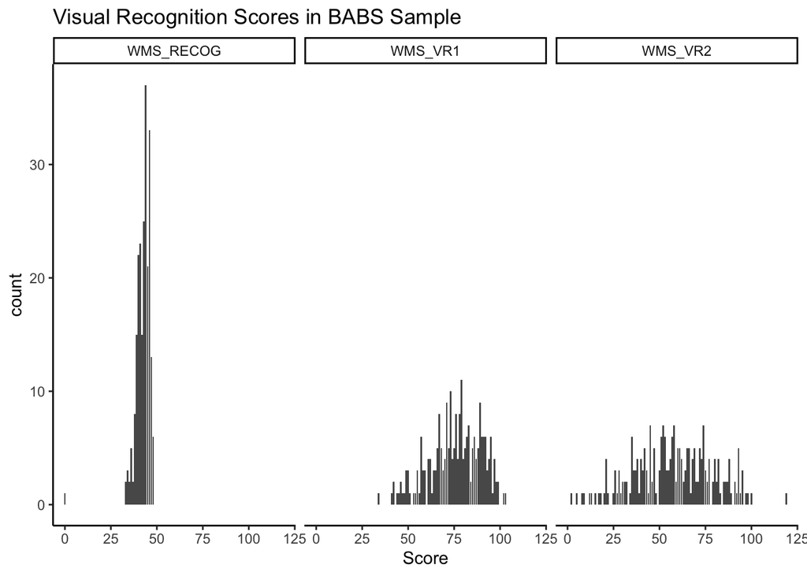

```r
#creating long data frame
d.WMS.long <- d.WMS %>%
  pivot_longer(names_to = "Facet", values_to = "Score", -c(BABS_ID, `AGE AT SESSION`))
#plotting distribution of scores**
p.WMS <- ggplot(d.WMS.long, aes(Score)) +
  geom_bar() +
  labs(title = "Visual Recognition Scores in BABS Sample") +
  theme_classic() + facet_grid(.~ Facet)
p.WMS
```

## Fluid Intelligence

### WASI-II Matrix Reasoning

Note: Also, need to look up the range of acceptable scores to verify values.

```r
d.matrix <- BABS.NP.sess1 %>% select(BABS_ID, `AGE AT SESSION`, WASI_MATRIX_SCORE) %>%
                                          distinct(BABS_ID, .keep_all = T) %>%
  mutate_at(vars(starts_with("WASI")), as.numeric)
#counting the number of observations and summarizing mean & SD
Matrix.sum <- d.matrix %>% describe() %>% select(-vars) %>% rownames_to_column(var = "Variable") %>%
  filter(Variable != "BABS_ID*") %>% filter(Variable != "AGE AT SESSION")

kable(Matrix.sum, col.names = c("Variable","N","Mean","SD","Median","Trimmed Mean","Median Abs. Deviation","Min","Max","Range","Skew","Kurtosis","SE"),
      caption = "WASI Matrix Reasoning Summary Table") %>% kable_styling()
```

WASI Matrix Reasoning Summary Table

| Variable | N | Mean | SD | Median | Trimmed Mean | Median Abs. Deviation | Min | Max | Range | Skew | Kurtosis | SE |
| --- | --- | --- | --- | --- | --- | --- | --- | --- | --- | --- | --- | --- |
| WASI_MATRIX_SCORE | 167 | 16.76647 | 3.861996 | 17 | 17.06667 | 2.9652 | 2 | 24 | 22 | -0.9094316 | 1.40055 | 0.2988502 |

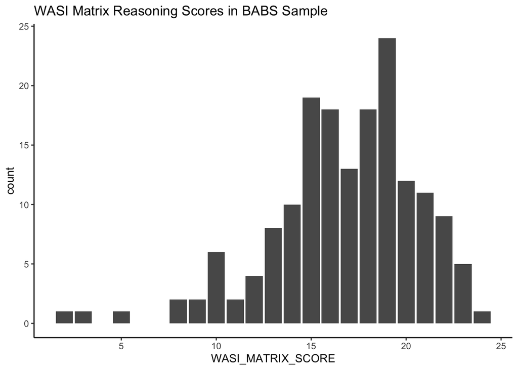

```r
#plotting distribution of scores
p.matrix <- ggplot(d.matrix, aes(WASI_MATRIX_SCORE)) +
  geom_bar() +
  labs(title = "WASI Matrix Reasoning Scores in BABS Sample") +
  theme_classic()
p.matrix
```

## Creativity

### Remote Associates Test

Note: Stopped administration after BABS_173. All values fall in allowable range (0-12).

```r
d.remoteAssoc <- BABS.NP.sess1 %>% select(BABS_ID, `AGE AT SESSION`, REMOTE_ASSOCIATES) %>%
                                          distinct(BABS_ID, .keep_all = T) %>%
   mutate_at(vars(starts_with("REMOTE")), as.numeric)
#counting the number of observations and summarizing mean & SD
remoteAssoc.sum <- d.remoteAssoc %>% describe() %>% select(-vars) %>% rownames_to_column(var = "Variable") %>%
  filter(Variable != "BABS_ID*") %>% filter(Variable != "AGE AT SESSION")

kable(remoteAssoc.sum, col.names = c("Variable","N","Mean","SD","Median","Trimmed Mean","Median Abs. Deviation","Min","Max","Range","Skew","Kurtosis","SE"),
      caption = "Remote Associates Summary Table") %>% kable_styling()
```

Remote Associates Summary Table

| Variable | N | Mean | SD | Median | Trimmed Mean | Median Abs. Deviation | Min | Max | Range | Skew | Kurtosis | SE |
| --- | --- | --- | --- | --- | --- | --- | --- | --- | --- | --- | --- | --- |
| REMOTE_ASSOCIATES | 145 | 9.868965 | 2.8413 | 11 | 10.49573 | 1.4826 | 0 | 12 | 12 | -2.065463 | 3.921883 | 0.2359572 |

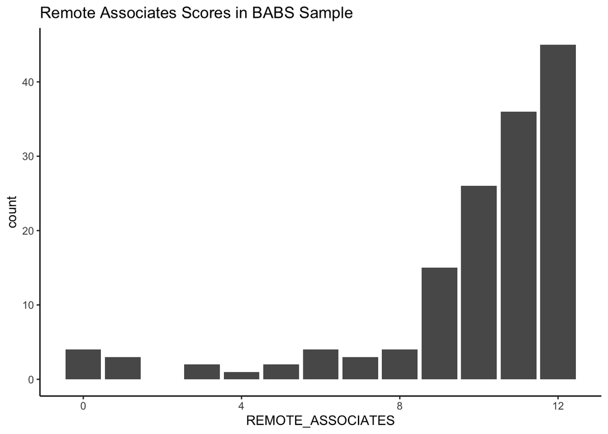

```r
#plotting distribution of scores
p.remoteAssoc <- ggplot(d.remoteAssoc, aes(REMOTE_ASSOCIATES)) +
  geom_bar() +
  labs(title = "Remote Associates Scores in BABS Sample") +
  theme_classic()
p.remoteAssoc
```

### Alternative Uses Task

Note: Unscored measure.

```r
d.altUse <- BABS.NP.sess1 %>% select(BABS_ID, `AGE AT SESSION`, ALTERTIVE_USES) %>%
                                          distinct(BABS_ID, .keep_all = T) %>%
   mutate_at(vars(starts_with("ALT")), as.numeric)
#counting the number of observations and summarizing mean & SD
altUses.sum <- d.altUse %>% describe() %>% select(-vars) %>% rownames_to_column(var = "Variable") %>%
  filter(Variable != "BABS_ID*") %>% filter(Variable != "AGE AT SESSION")

kable(altUses.sum, col.names = c("Variable","N","Mean","SD","Median","Trimmed Mean","Median Abs. Deviation","Min","Max","Range","Skew","Kurtosis","SE"),
      caption = "Alternative Uses Summary Table") %>% kable_styling()
```

Alternative Uses Summary Table

| Variable | N | Mean | SD | Median | Trimmed Mean | Median Abs. Deviation | Min | Max | Range | Skew | Kurtosis | SE |
| --- | --- | --- | --- | --- | --- | --- | --- | --- | --- | --- | --- | --- |
| ALTERTIVE_USES | 4 | 25 | 3.265986 | 25 | 25 | 2.9652 | 21 | 29 | 8 | 0 | -1.875 | 1.632993 |

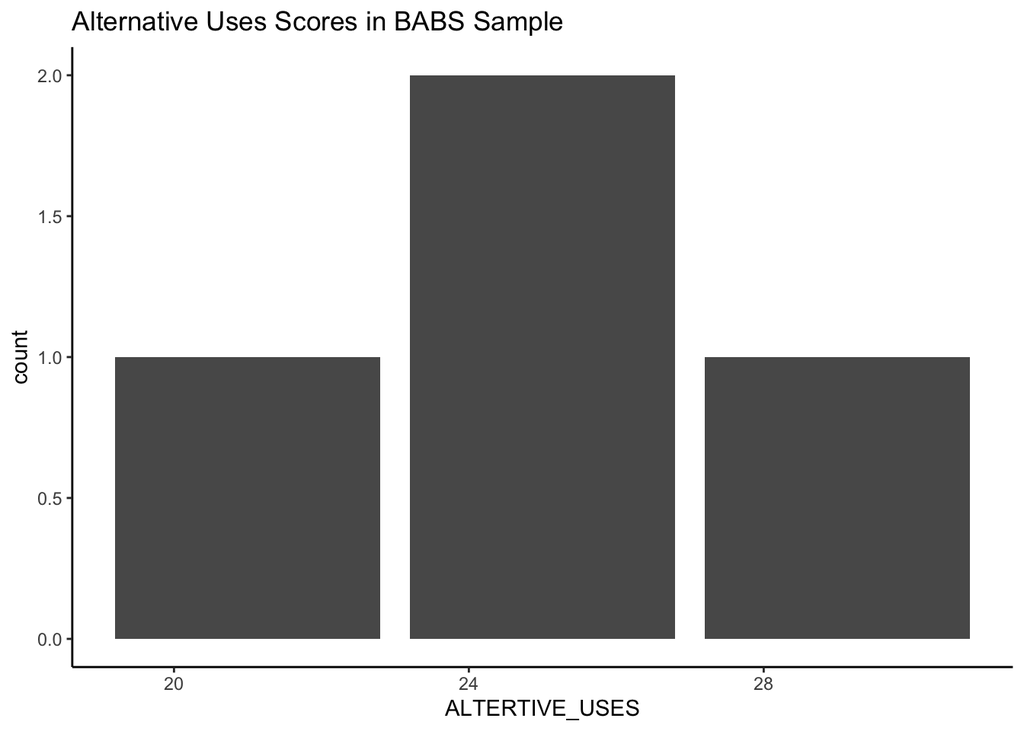

```r
#plotting distribution of scores
p.altUse <- ggplot(d.altUse, aes(ALTERTIVE_USES)) +
  geom_bar() +
  labs(title = "Alternative Uses Scores in BABS Sample") +
  theme_classic()
p.altUse
```

## Crystalized Intelligence

### WASI-II Vocab

Note: need to look up the range of acceptable scores to verify values.

```r
#creating data frame with relevant variables
d.vocab <- BABS.NP.sess1 %>% select(BABS_ID, `AGE AT SESSION`, WASI_VOCAB_SCORE) %>%
                                          distinct(BABS_ID, .keep_all = T) %>%
   mutate_at(vars(starts_with("WASI")), as.numeric)
#counting the number of observations and summarizing mean & SD
Vocab.sum <- d.vocab %>% describe() %>% select(-vars) %>% rownames_to_column(var = "Variable") %>%
  filter(Variable != "BABS_ID*") %>% filter(Variable != "AGE AT SESSION")

kable(Matrix.sum, col.names = c("Variable","N","Mean","SD","Median","Trimmed Mean","Median Abs. Deviation","Min","Max","Range","Skew","Kurtosis","SE"),
      caption = "WASI Vocab Summary Table") %>% kable_styling()
```

| Variable | N | Mean | SD | Median | Trimmed Mean | Median Abs. Deviation | Min | Max | Range | Skew | Kurtosis | SE |
| --- | --- | --- | --- | --- | --- | --- | --- | --- | --- | --- | --- | --- |
| WASI_MATRIX_SCORE | 167 | 16.76647 | 3.861996 | 17 | 17.06667 | 2.9652 | 2 | 24 | 22 | -0.9094316 | 1.40055 | 0.2988502 |

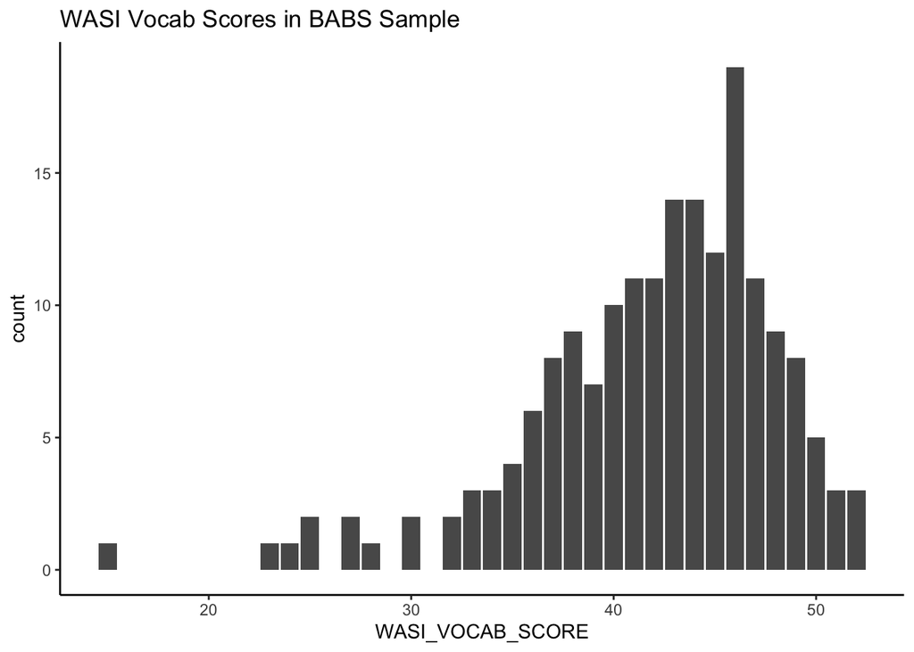

```r
#plotting distribution of scores
p.vocab <- ggplot(d.vocab, aes(WASI_VOCAB_SCORE)) +
  geom_bar() +
  labs(title = "WASI Vocab Scores in BABS Sample") +
  theme_classic()
p.vocab
```

### C-Test

Note: Stopped administration after BABS_173. Unknown range of acceptable values.

```r
#creating data frame with relevant variables
d.cTest <- BABS.NP.sess1 %>% select(BABS_ID, `AGE AT SESSION`, CTEST) %>%
                                          distinct(BABS_ID, .keep_all = T) %>%
   mutate_at(vars(starts_with("CTEST")), as.numeric)
#counting the number of observations and summarizing mean & SD
cTest.sum <- d.cTest %>% describe() %>% select(-vars) %>% rownames_to_column(var = "Variable") %>%
  filter(Variable != "BABS_ID*") %>% filter(Variable != "AGE AT SESSION")

kable(cTest.sum, col.names = c("Variable","N","Mean","SD","Median","Trimmed Mean","Median Abs. Deviation","Min","Max","Range","Skew","Kurtosis","SE"),
      caption = "C-Test Summary Table") %>% kable_styling()
```

C-Test Summary Table

| Variable | N | Mean | SD | Median | Trimmed Mean | Median Abs. Deviation | Min | Max | Range | Skew | Kurtosis | SE |
| --- | --- | --- | --- | --- | --- | --- | --- | --- | --- | --- | --- | --- |
| CTEST | 143 | -5.104895 | 7.671709 | -3 | -3.46087 | 2.9652 | -50 | 0 | 50 | -3.381046 | 13.12076 | 0.6415405 |

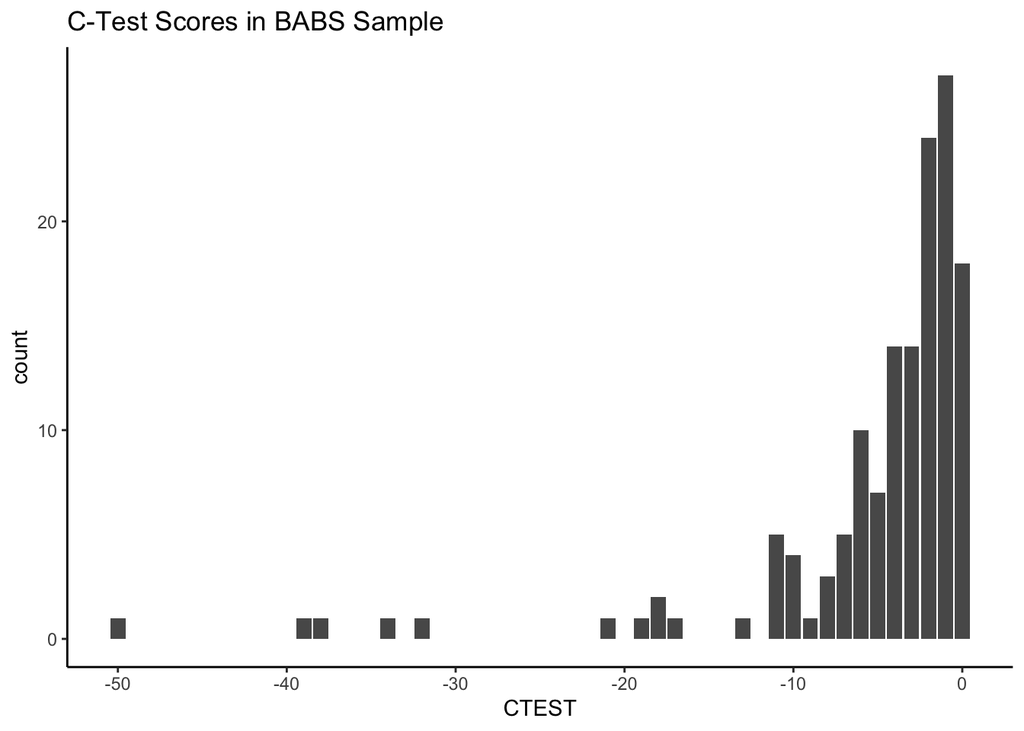

```r
#plotting distribution of scores
p.cTest <- ggplot(d.cTest, aes(CTEST)) +
  geom_bar() +
  labs(title = "C-Test Scores in BABS Sample") +
  theme_classic()
p.cTest
```

# Individual Difference Questionnaires

## Lifestyle

### Lifetime Experiences Questionnaire (LEQ)

Variable number of responses across items; will need to verify with notes to confirm.

```r
#creating data frame with relevant variables
d.LEQ <- BABS.NP.sess1 %>% select(BABS_ID, `AGE AT SESSION`, starts_with("LEQ")) %>%
                                          distinct(BABS_ID, .keep_all = T) %>%
  mutate_at(vars(starts_with("LEQ")), as.numeric) %>%
  mutate(LEQ_YA_total = (LEQ_YA_A + LEQ_YA_B)*1.05 + LEQ_YA_C,
         LEQ_MA_total = (LEQ_MID_A + LEQ_MID_B)*0.25 + LEQ_MID_D + LEQ_MID_C,
         LEQ_OA_total = (LEQ_LATE_A*0.4) + LEQ_LATE_C + LEQ_LATE_B,
         LEQ_total = LEQ_YA_total + LEQ_MA_total + LEQ_OA_total)
#counting the number of observations and summarizing mean & SD
LEQ.sum <- d.LEQ %>% describe() %>% select(-vars) %>% rownames_to_column(var = "Variable") %>%
  filter(Variable != "BABS_ID*") %>% filter(Variable != "AGE AT SESSION") %>% filter(Variable != "LEQ NOTES")

kable(LEQ.sum, col.names = c("Variable","N","Mean","SD","Median","Trimmed Mean","Median Abs. Deviation","Min","Max","Range","Skew","Kurtosis","SE"),
      caption = "LEQ Summary Table") %>% kable_styling()
```

LEQ Summary Table

| Variable | N | Mean | SD | Median | Trimmed Mean | Median Abs. Deviation | Min | Max | Range | Skew | Kurtosis | SE |
| --- | --- | --- | --- | --- | --- | --- | --- | --- | --- | --- | --- | --- |
| LEQ_YA_A | 189 | 8.0000000 | 0.000000 | 8.000 | 8.000000 | 0.00000 | 8.0 | 8.00 | 0.00 | NaN | NaN | 0.0000000 |
| LEQ_YA_B | 185 | 15.3783784 | 7.522796 | 18.000 | 15.174497 | 11.86080 | 0.0 | 36.50 | 36.50 | 0.2931766 | -0.1800311 | 0.5530870 |
| LEQ_YA_C | 185 | 20.6270270 | 5.181103 | 20.000 | 20.382550 | 5.93040 | 11.0 | 37.00 | 26.00 | 0.3950745 | -0.1656887 | 0.3809223 |
| LEQ_MID_A | 181 | 54.4254144 | 15.195073 | 62.000 | 57.006897 | 7.41300 | 0.0 | 70.00 | 70.00 | -1.4541068 | 1.3463203 | 1.1294409 |
| LEQ_MID_B | 172 | 21.6162791 | 9.157068 | 24.000 | 22.014493 | 11.86080 | 8.0 | 32.00 | 24.00 | -0.1237251 | -1.4768949 | 0.6982199 |
| LEQ_MID_C | 175 | 4.5412857 | 6.049958 | 0.000 | 3.432092 | 0.00000 | 0.0 | 25.50 | 25.50 | 1.2744415 | 0.8670184 | 0.4573339 |
| LEQ_MID_D | 186 | 19.7258065 | 4.738010 | 19.000 | 19.546667 | 4.44780 | 9.0 | 37.00 | 28.00 | 0.4565963 | 0.1655540 | 0.3474077 |
| LEQ_LATE_A | 174 | 26.2959770 | 6.883845 | 27.000 | 26.646429 | 5.93040 | 0.0 | 39.00 | 39.00 | -0.7499407 | 1.4487453 | 0.5218630 |
| LEQ_LATE_B | 166 | 0.4777108 | 1.652927 | 0.000 | 0.000000 | 0.00000 | 0.0 | 8.00 | 8.00 | 3.4827198 | 11.1463508 | 0.1282920 |
| LEQ_LATE_C | 170 | 18.1617647 | 4.982693 | 17.500 | 18.110294 | 3.70650 | 0.0 | 33.00 | 33.00 | -0.4096530 | 2.2679264 | 0.3821551 |
| LEQ_NOTES | 0 | NaN | NA | NA | NaN | NA | Inf | -Inf | -Inf | NA | NA | NA |
| LEQ_YA_total | 182 | 45.2876374 | 10.314854 | 46.300 | 45.353082 | 9.56277 | 19.4 | 76.20 | 56.80 | -0.0278747 | 0.0702363 | 0.7645878 |
| LEQ_MA_total | 164 | 43.5318598 | 10.453774 | 44.125 | 43.809091 | 11.11950 | 12.0 | 67.75 | 55.75 | -0.2301197 | -0.3568119 | 0.8163026 |
| LEQ_OA_total | 164 | 28.8926829 | 7.299874 | 28.200 | 28.998485 | 5.93040 | 0.0 | 45.20 | 45.20 | -0.5979130 | 2.2602854 | 0.5700244 |
| LEQ_total | 140 | 117.1587500 | 22.674804 | 121.125 | 117.826562 | 23.64747 | 48.2 | 178.40 | 130.20 | -0.2961999 | -0.1479297 | 1.9163707 |

### BABS Physical Activities Questionnaire

Note: Unclear to me what this instrument is.

```r
d.physAct <- BABS.NP.sess1 %>% select(BABS_ID, `AGE AT SESSION`, starts_with("PHYSICAL_ACT")) %>%
                                          distinct(BABS_ID, .keep_all = T) %>%
  mutate_at(vars(starts_with("PHYSICAL_ACT")), as.numeric)
#counting the number of observations and summarizing mean & SD
physAct.sum <- d.physAct %>% describe() %>% select(-vars) %>% rownames_to_column(var = "Variable") %>%
  filter(Variable != "BABS_ID*") %>% filter(Variable != "AGE AT SESSION")

kable(physAct.sum, col.names = c("Variable","N","Mean","SD","Median","Trimmed Mean","Median Abs. Deviation","Min","Max","Range","Skew","Kurtosis","SE"),
      caption = "Physical Activity Summary Table") %>% kable_styling()
```

Physical Activity Summary Table

| Variable | N | Mean | SD | Median | Trimmed Mean | Median Abs. Deviation | Min | Max | Range | Skew | Kurtosis | SE |
| --- | --- | --- | --- | --- | --- | --- | --- | --- | --- | --- | --- | --- |
| PHYSICAL_ACTIVITY_WALKING_TIMES | 27 | 6.111111 | 5.1465697 | 5.00 | 5.260870 | 2.965200 | 2.0 | 28.0 | 26.0 | 2.8368848 | 9.3003028 | 0.9904578 |
| PHYSICAL_ACTIVITY_WALKING_MINUTES | 27 | 40.018518 | 25.3629354 | 30.00 | 37.630435 | 22.239000 | 5.0 | 120.0 | 115.0 | 1.1578784 | 1.3442719 | 4.8810992 |
| PHYSICAL_ACTIVITIES_WALKING_MONTHS | 27 | 11.037037 | 2.2271313 | 12.00 | 11.478261 | 0.000000 | 4.0 | 12.0 | 8.0 | -1.9758671 | 2.4905781 | 0.4286116 |
| PHYSICAL_ACTIVITIES_CHORES_TIMES | 22 | 7.136364 | 5.2761409 | 5.00 | 7.055556 | 4.447800 | 1.0 | 14.0 | 13.0 | 0.3205541 | -1.6948595 | 1.1248770 |
| PHYSICAL_ACTIVITIES_CHORES_MINUTES | 22 | 45.454546 | 40.5882076 | 30.00 | 37.500000 | 22.239000 | 10.0 | 180.0 | 170.0 | 1.8524894 | 3.1846191 | 8.6534349 |
| PHYSICAL_ACTIVITIES_CHORES_MONTHS | 22 | 12.000000 | 0.0000000 | 12.00 | 12.000000 | 0.000000 | 12.0 | 12.0 | 0.0 | NaN | NaN | 0.0000000 |
| PHYSICAL_ACTIVITIES_MOWING_TIMES | 1 | 1.000000 | NA | 1.00 | 1.000000 | 0.000000 | 1.0 | 1.0 | 0.0 | NA | NA | NA |
| PHYSICAL_ACTIVITIES_MOWING_MINUTES | 1 | 120.000000 | NA | 120.00 | 120.000000 | 0.000000 | 120.0 | 120.0 | 0.0 | NA | NA | NA |
| PHYSICAL_ACTIVITIES_MOWING_MONTHS | 1 | 3.500000 | NA | 3.50 | 3.500000 | 0.000000 | 3.5 | 3.5 | 0.0 | NA | NA | NA |
| PHYSICAL_ACTIVITIES_RAKING_TIMES | 8 | 3.000000 | 2.3904572 | 2.00 | 3.000000 | 1.482600 | 1.0 | 7.0 | 6.0 | 0.6039640 | -1.5146875 | 0.8451543 |
| PHYSICAL_ACTIVITIES_RAKING_MINUTES | 8 | 91.000000 | 62.5482671 | 120.00 | 91.000000 | 44.478000 | 3.0 | 180.0 | 177.0 | -0.2782893 | -1.5204701 | 22.1141519 |
| PHYSICAL_ACTIVITIES_RAKING_MONTHS | 8 | 6.125000 | 4.1896983 | 6.00 | 6.125000 | 5.189100 | 1.0 | 12.0 | 11.0 | 0.2904823 | -1.5971630 | 1.4812820 |
| PHYSICAL_ACTIVITIES_GARDENING_TIMES | 13 | 5.000000 | 4.4534631 | 4.00 | 4.545454 | 4.447800 | 1.0 | 14.0 | 13.0 | 1.0764195 | -0.2548223 | 1.2351684 |
| PHYSICAL_ACTIVITIES_GARDENING_MINUTES | 13 | 66.923077 | 67.0055489 | 60.00 | 56.363636 | 44.478000 | 10.0 | 240.0 | 230.0 | 1.5698993 | 1.1351586 | 18.5839956 |
| PHYSICAL_ACTIVITIES_GARDENING_MONTHS | 13 | 7.538462 | 3.0170456 | 6.00 | 7.545454 | 1.482600 | 3.0 | 12.0 | 9.0 | 0.3935966 | -1.3704721 | 0.8367779 |
| PHYSICAL_ACTIVITIES_HIKING_TIMES | 3 | 1.333333 | 0.5773503 | 1.00 | 1.333333 | 0.000000 | 1.0 | 2.0 | 1.0 | 0.3849002 | -2.3333333 | 0.3333333 |
| PHYSICAL_ACTIVITIES_HIKING_MINUTES | 3 | 110.000000 | 75.4983444 | 120.00 | 110.000000 | 88.956000 | 30.0 | 180.0 | 150.0 | -0.1301295 | -2.3333333 | 43.5889894 |
| PHYSICAL_ACTIVITIES_HIKING_MONTHS | 2 | 12.000000 | 0.0000000 | 12.00 | 12.000000 | 0.000000 | 12.0 | 12.0 | 0.0 | NaN | NaN | 0.0000000 |
| PHYSICAL_ACTIVITIES_JOGGING_TIMES | 0 | NaN | NA | NA | NaN | NA | Inf | -Inf | -Inf | NA | NA | NA |
| PHYSICAL_ACTIVITIES_JOGGING_MINUTES | 0 | NaN | NA | NA | NaN | NA | Inf | -Inf | -Inf | NA | NA | NA |
| PHYSICAL_ACTIVITIES_JOGGING_MONTHS | 0 | NaN | NA | NA | NaN | NA | Inf | -Inf | -Inf | NA | NA | NA |
| PHYSICAL_ACTIVITIES_BIKING_TIMES | 1 | 1.000000 | NA | 1.00 | 1.000000 | 0.000000 | 1.0 | 1.0 | 0.0 | NA | NA | NA |
| PHYSICAL_ACTIVITIES_BIKING_MINUTES | 1 | 90.000000 | NA | 90.00 | 90.000000 | 0.000000 | 90.0 | 90.0 | 0.0 | NA | NA | NA |
| PHYSICAL_ACTIVITIES_BIKING_MONTHS | 1 | 6.000000 | NA | 6.00 | 6.000000 | 0.000000 | 6.0 | 6.0 | 0.0 | NA | NA | NA |
| PHYSICAL_ACTIVITIES_STATIONARY_BIKE_TIMES | 7 | 3.857143 | 4.1403934 | 2.00 | 3.857143 | 1.482600 | 1.0 | 12.0 | 11.0 | 1.0166144 | -0.7332483 | 1.5649216 |
| PHYSICAL_ACTIVITIES_STATIONARY_BIKE_MINUTES | 7 | 27.142857 | 15.7736972 | 20.00 | 27.142857 | 7.413000 | 15.0 | 60.0 | 45.0 | 1.1360145 | -0.1977402 | 5.9618972 |
| PHYSICAL_ACTIVITIES_STATIONARY_BIKE_MONTHS | 7 | 9.285714 | 3.5923199 | 12.00 | 9.285714 | 0.000000 | 4.0 | 12.0 | 8.0 | -0.4577127 | -1.8524116 | 1.3577693 |
| PHYSICAL_ACTIVITIES_DANCING_TIMES | 7 | 4.142857 | 4.7409061 | 2.00 | 4.142857 | 1.482600 | 1.0 | 14.0 | 13.0 | 1.1545525 | -0.2382133 | 1.7918941 |
| PHYSICAL_ACTIVITIES_DANCING_MINUTES | 7 | 27.142857 | 19.5484745 | 20.00 | 27.142857 | 7.413000 | 10.0 | 60.0 | 50.0 | 0.7279546 | -1.4606979 | 7.3886289 |
| PHYSICAL_ACTIVITIES_DANCING_MONTHS | 7 | 9.428571 | 3.2071349 | 10.00 | 9.428571 | 2.965200 | 4.0 | 12.0 | 8.0 | -0.6448208 | -1.4633409 | 1.2121831 |
| PHYSICAL_ACTIVITIES_AEROBICS_TIMES | 4 | 2.750000 | 2.2173558 | 2.00 | 2.750000 | 0.741300 | 1.0 | 6.0 | 5.0 | 0.6449505 | -1.7426566 | 1.1086779 |
| PHYSICAL_ACTIVITIES_AEROBICS_MINUTES | 4 | 35.000000 | 21.2132034 | 32.50 | 35.000000 | 22.239000 | 15.0 | 60.0 | 45.0 | 0.1374930 | -2.2453704 | 10.6066017 |
| PHYSICAL_ACTIVITIES_AEROBICS_MONTHS | 4 | 7.750000 | 4.9244289 | 8.00 | 7.750000 | 5.930400 | 3.0 | 12.0 | 9.0 | -0.0133460 | -2.4221158 | 2.4622145 |
| PHYSICAL_ACTIVITIES_BOWLING_TIMES | 1 | 1.000000 | NA | 1.00 | 1.000000 | 0.000000 | 1.0 | 1.0 | 0.0 | NA | NA | NA |
| PHYSICAL_ACTIVITIES_BOWLING_MINUTES | 1 | 60.000000 | NA | 60.00 | 60.000000 | 0.000000 | 60.0 | 60.0 | 0.0 | NA | NA | NA |
| PHYSICAL_ACTIVITIES_BOWLING_MONTHS | 1 | 3.000000 | NA | 3.00 | 3.000000 | 0.000000 | 3.0 | 3.0 | 0.0 | NA | NA | NA |
| PHYSICAL_ACTIVITIES_GOLF_TIMES | 1 | 4.000000 | NA | 4.00 | 4.000000 | 0.000000 | 4.0 | 4.0 | 0.0 | NA | NA | NA |
| PHYSICAL_ACTIVITIES_GOLF_MINUTES | 1 | 270.000000 | NA | 270.00 | 270.000000 | 0.000000 | 270.0 | 270.0 | 0.0 | NA | NA | NA |
| PHYSICAL_ACTIVITIES_GOLF_MONTHS | 1 | 12.000000 | NA | 12.00 | 12.000000 | 0.000000 | 12.0 | 12.0 | 0.0 | NA | NA | NA |
| PHYSICAL_ACTIVITIES_GENERAL_EXCERSIZE_TIMES | 8 | 9.875000 | 4.4860896 | 11.00 | 9.875000 | 4.447800 | 2.0 | 14.0 | 12.0 | -0.4848061 | -1.4479880 | 1.5860722 |
| PHYSICAL_ACTIVITIES_GENERAL_EXCERSIZE_MINUTES | 8 | 42.500000 | 34.6410162 | 30.00 | 42.500000 | 3.706500 | 5.0 | 120.0 | 115.0 | 1.2325075 | 0.3200684 | 12.2474487 |
| PHYSICAL_ACTIVITIES_GENERAL_EXCERSIZE_MONTHS | 8 | 12.000000 | 0.0000000 | 12.00 | 12.000000 | 0.000000 | 12.0 | 12.0 | 0.0 | NaN | NaN | 0.0000000 |
| PHYSICAL_ACTIVITIES_SWIMMING_TIMES | 3 | 7.333333 | 6.1101009 | 6.00 | 7.333333 | 5.930400 | 2.0 | 14.0 | 12.0 | 0.2078266 | -2.3333333 | 3.5276684 |
| PHYSICAL_ACTIVITIES_SWIMMING_MINUTES | 3 | 36.666667 | 20.8166600 | 30.00 | 36.666667 | 14.826000 | 20.0 | 60.0 | 40.0 | 0.2874095 | -2.3333333 | 12.0185043 |
| PHYSICAL_ACTIVITIES_SWIMMING_MONTHS | 3 | 12.000000 | 0.0000000 | 12.00 | 12.000000 | 0.000000 | 12.0 | 12.0 | 0.0 | NaN | NaN | 0.0000000 |
| PHYSICAL_ACTIVITIES_OTHER_TEXT | 0 | NaN | NA | NA | NaN | NA | Inf | -Inf | -Inf | NA | NA | NA |
| PHYSICAL_ACTIVITIES_OTHER_TIMES | 12 | 4.770833 | 4.3945451 | 3.50 | 4.225000 | 2.779875 | 1.0 | 14.0 | 13.0 | 0.9529133 | -0.7219357 | 1.2685959 |
| PHYSICAL_ACTIVITIES_OTHER_MINUTES | 12 | 56.666667 | 49.0979232 | 50.00 | 52.500000 | 55.597500 | 5.0 | 150.0 | 145.0 | 0.6224955 | -1.1605337 | 14.1733496 |
| PHYSICAL_ACTIVITIES_OTHER_MONTHS | 12 | 7.083333 | 5.2476546 | 8.50 | 7.200000 | 5.189100 | 1.0 | 12.0 | 11.0 | -0.0984574 | -2.0572227 | 1.5148674 |
| PHYSICAL_ACTIVITIES_MILES_WALKED | 8 | 16.250000 | 6.1586177 | 15.00 | 16.250000 | 7.413000 | 10.0 | 28.0 | 18.0 | 0.6200833 | -1.0154292 | 2.1774002 |
| PHYSICAL_ACTIVITIES_PACE | 0 | NaN | NA | NA | NaN | NA | Inf | -Inf | -Inf | NA | NA | NA |
| PHYSICAL_ACTIVITIES_STAIRS | 27 | 36.000000 | 35.0406358 | 25.00 | 31.608696 | 25.204200 | 0.0 | 140.0 | 140.0 | 1.3627633 | 1.1331370 | 6.7435735 |
| PHYSICAL_ACTIVITIES_SEDENTARY_TIME | 27 | 13.185185 | 4.0647361 | 12.00 | 12.978261 | 2.965200 | 5.0 | 22.5 | 17.5 | 0.6027400 | -0.1882087 | 0.7822588 |
| PHYSICAL_ACTIVITIES_ACTIVITY_CHANGE | 0 | NaN | NA | NA | NaN | NA | Inf | -Inf | -Inf | NA | NA | NA |
| PHYSICAL_ACTIVITIES_NOTES | 0 | NaN | NA | NA | NaN | NA | Inf | -Inf | -Inf | NA | NA | NA |
| PHYSICAL_ACTIVITY_MINUTES | 200 | 210.822454 | 148.1099985 | 192.45 | 194.526646 | 138.808425 | 0.0 | 975.0 | 975.0 | 1.3730519 | 3.4106745 | 10.4729584 |

## Depressive and Anxious Traits

### Geriatric Depression Questionnaire (GDS)

Allowable range is 0-30 (integers only). The following participants have scores that are not integers: BABS106 (10.5), BABS111 (0.5), BABS114 (3.5), BABS118 (7.5).

```r
d.GDS <- BABS.NP.sess1 %>% select(BABS_ID, `AGE AT SESSION`, GDS) %>%
                                          distinct(BABS_ID, .keep_all = T) %>%
  mutate_at(vars(starts_with("GDS")), as.numeric)
#counting the number of observations and summarizing mean & SD
GDS.sum <- d.GDS %>% describe() %>% select(-vars) %>% rownames_to_column(var = "Variable") %>%
  filter(Variable != "BABS_ID*") %>% filter(Variable != "AGE AT SESSION")

kable(GDS.sum, col.names = c("Variable","N","Mean","SD","Median","Trimmed Mean","Median Abs. Deviation","Min","Max","Range","Skew","Kurtosis","SE"),
      caption = "GDS Summary Table") %>% kable_styling()
```

GDS Summary Table

| Variable | N | Mean | SD | Median | Trimmed Mean | Median Abs. Deviation | Min | Max | Range | Skew | Kurtosis | SE |
| --- | --- | --- | --- | --- | --- | --- | --- | --- | --- | --- | --- | --- |
| GDS | 230 | 3.565217 | 3.495176 | 3 | 3.019022 | 2.9652 | 0 | 17 | 17 | 1.308315 | 1.307801 | 0.2304651 |

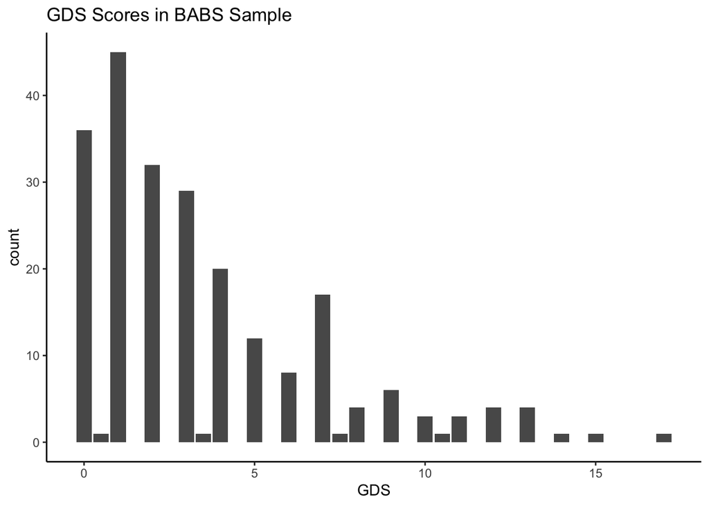

```r
#plotting distribution of scores
p.GDS <- ggplot(d.GDS, aes(GDS)) +
  geom_bar() +
  labs(title = "GDS Scores in BABS Sample") +
  theme_classic()
p.GDS
```

### Mood and Anxiety Symptom Questionnaire (MASQ-30)

Subscores range from 10-50 (integers only). The following participants have scores that are not integers: BABS070 (MASQ_GD = 13.5, MASQ_AD = 26.5), BABS072 (MASQ_GD = 16.5), BABS111 (MASQ_AA = 14.5).

```r
d.MASQ <- BABS.NP.sess1 %>% select(BABS_ID, `AGE AT SESSION`, starts_with("MASQ")) %>%
                                          distinct(BABS_ID, .keep_all = T) %>%
  mutate_at(vars(starts_with("MASQ")), as.numeric)
#counting the number of observations and summarizing mean & SD
MASQ.sum <- d.MASQ %>% describe() %>% select(-vars) %>% rownames_to_column(var = "Variable") %>%
  filter(Variable != "BABS_ID*") %>% filter(Variable != "AGE AT SESSION")

kable(MASQ.sum, col.names = c("Variable","N","Mean","SD","Median","Trimmed Mean","Median Abs. Deviation","Min","Max","Range","Skew","Kurtosis","SE"),
      caption = "MASQ Summary Table") %>% kable_styling()
```

MASQ Summary Table

| Variable | N | Mean | SD | Median | Trimmed Mean | Median Abs. Deviation | Min | Max | Range | Skew | Kurtosis | SE |
| --- | --- | --- | --- | --- | --- | --- | --- | --- | --- | --- | --- | --- |
| MASQ_GD | 234 | 14.60684 | 4.502898 | 13.75 | 13.89362 | 4.07715 | 10 | 36 | 26 | 1.6248707 | 3.1639092 | 0.2943637 |
| MASQ_AD | 234 | 26.17735 | 7.521041 | 26.00 | 26.06649 | 7.41300 | 10 | 49 | 39 | 0.2081069 | -0.2486058 | 0.4916658 |
| MASQ_AA | 234 | 12.71154 | 3.359554 | 12.00 | 12.16223 | 2.96520 | 10 | 43 | 33 | 3.8350636 | 27.4523673 | 0.2196209 |

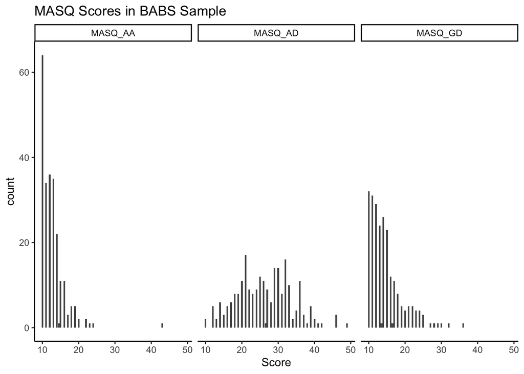

```r
#creating long data frame
d.MASQ.long <- d.MASQ %>%
  pivot_longer(names_to = "Facet", values_to = "Score", -c(BABS_ID, `AGE AT SESSION`))
#plotting distribution of scores**
p.MASQ <- ggplot(d.MASQ.long, aes(Score)) +
  geom_bar() +
  labs(title = "MASQ Scores in BABS Sample") +
  theme_classic() + facet_grid(.~ Facet)
p.MASQ
```

### Penn State Worry Questionnaire

Scores range from 16-80 (integers only). The following participants have scores that are not integers: BABS029 (50.13), BABS038 (21.9375), BABS041(39.31), BABS045 (55.47), BABS083 (29.87), BABS092 (45.87).

```r
d.PSWQ <- BABS.NP.sess1 %>% select(BABS_ID, `AGE AT SESSION`, PSWQ) %>%
                                          distinct(BABS_ID, .keep_all = T) %>%
  mutate_at(vars(starts_with("PSWQ")), as.numeric)
#counting the number of observations and summarizing mean & SD
PSWQ.sum <- d.PSWQ %>% describe() %>% select(-vars) %>% rownames_to_column(var = "Variable") %>%
  filter(Variable != "BABS_ID*") %>% filter(Variable != "AGE AT SESSION")

kable(PSWQ.sum, col.names = c("Variable","N","Mean","SD","Median","Trimmed Mean","Median Abs. Deviation","Min","Max","Range","Skew","Kurtosis","SE"),
      caption = "Penn State Worry Summary Table") %>% kable_styling()
```

Penn State Worry Summary Table

| Variable | N | Mean | SD | Median | Trimmed Mean | Median Abs. Deviation | Min | Max | Range | Skew | Kurtosis | SE |
| --- | --- | --- | --- | --- | --- | --- | --- | --- | --- | --- | --- | --- |
| PSWQ | 186 | 38.26122 | 13.82856 | 36 | 37.19767 | 13.3434 | 16 | 78 | 62 | 0.6452025 | -0.2310664 | 1.013959 |

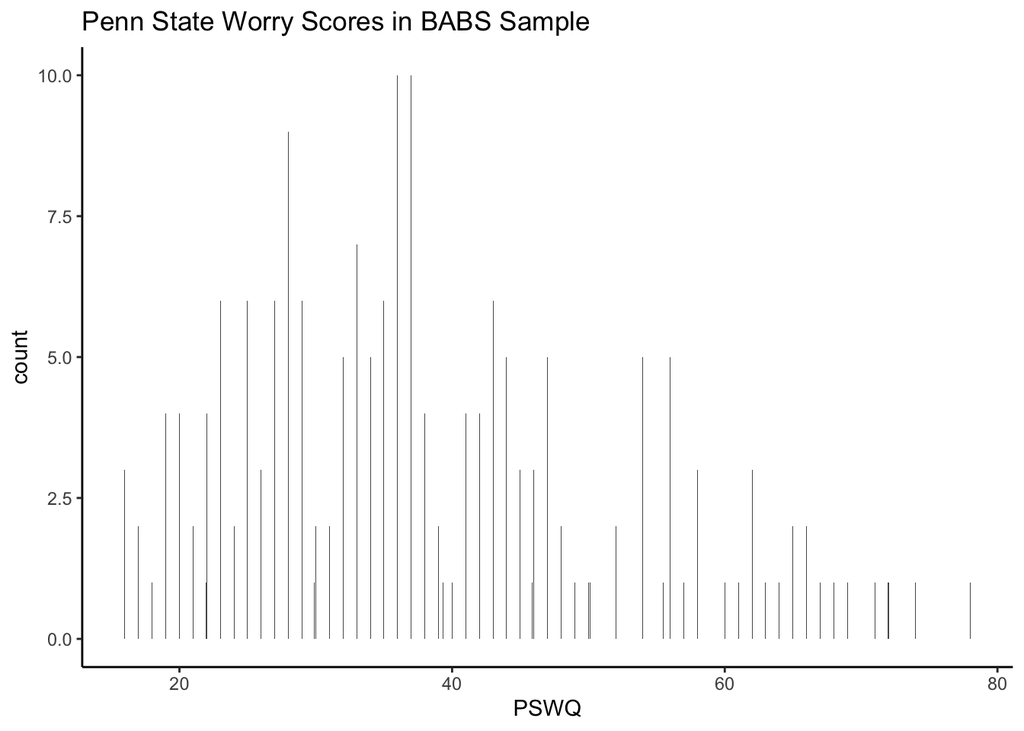

```r
#plotting distribution of scores
p.PSWQ <- ggplot(d.PSWQ, aes(PSWQ)) +
  geom_bar() +
  labs(title = "Penn State Worry Scores in BABS Sample") +
  theme_classic()
p.PSWQ
```

## Sleep

### Pittsburgh Sleep Quality Index (PSQI)

BABS284 (PSQI_DISTB = 12; range=0-3). Integer values only acceptable; BABS057 (PSQI_SLPQUAL = 1.5), BABS159 (PSQI_SLPQUAL = 1.5).

```r
d.PSQI <- BABS.NP.sess1 %>% select(BABS_ID, `AGE AT SESSION`, starts_with("PSQI")) %>%
                                          distinct(BABS_ID, .keep_all = T) %>%
  mutate_at(vars(starts_with("PSQI")), as.numeric)
#counting the number of observations and summarizing mean & SD
PSQI.sum <- d.PSQI %>% describe() %>% select(-vars) %>% rownames_to_column(var = "Variable") %>%
  filter(Variable != "BABS_ID*") %>% filter(Variable != "AGE AT SESSION")

kable(PSQI.sum, col.names = c("Variable","N","Mean","SD","Median","Trimmed Mean","Median Abs. Deviation","Min","Max","Range","Skew","Kurtosis","SE"),
      caption = "Pittsburgh Sleep Quality Summary Table") %>% kable_styling()
```

Pittsburgh Sleep Quality Summary Table

| Variable | N | Mean | SD | Median | Trimmed Mean | Median Abs. Deviation | Min | Max | Range | Skew | Kurtosis | SE |
| --- | --- | --- | --- | --- | --- | --- | --- | --- | --- | --- | --- | --- |
| PSQI_DURAT | 190 | 0.4947368 | 0.6803934 | 0 | 0.3750000 | 0.0000 | 0 | 3 | 3 | 1.2219989 | 0.9637829 | 0.0493609 |
| PSQI_DISTB | 192 | 1.3958333 | 0.9263922 | 1 | 1.2922078 | 0.0000 | 0 | 12 | 12 | 7.9100651 | 86.6640169 | 0.0668566 |
| PSQI_LATEN | 192 | 0.8958333 | 0.9597029 | 1 | 0.7467532 | 1.4826 | 0 | 3 | 3 | 0.8790850 | -0.1960481 | 0.0692606 |
| PSQI_DAYDYS | 192 | 0.5104167 | 0.6138846 | 0 | 0.4415584 | 0.0000 | 0 | 3 | 3 | 0.9061689 | 0.4574283 | 0.0443033 |
| PSQI_HSE | 190 | 0.5842105 | 0.8733340 | 0 | 0.4013158 | 0.0000 | 0 | 3 | 3 | 1.4733705 | 1.3058614 | 0.0633583 |
| PSQI_SLPQUAL | 191 | 0.8534031 | 0.6215231 | 1 | 0.8169935 | 0.0000 | 0 | 2 | 2 | 0.0900691 | -0.5441395 | 0.0449718 |
| PSQI_MEDS | 191 | 0.6178010 | 1.0738506 | 0 | 0.3986928 | 0.0000 | 0 | 3 | 3 | 1.4835306 | 0.5880823 | 0.0777011 |

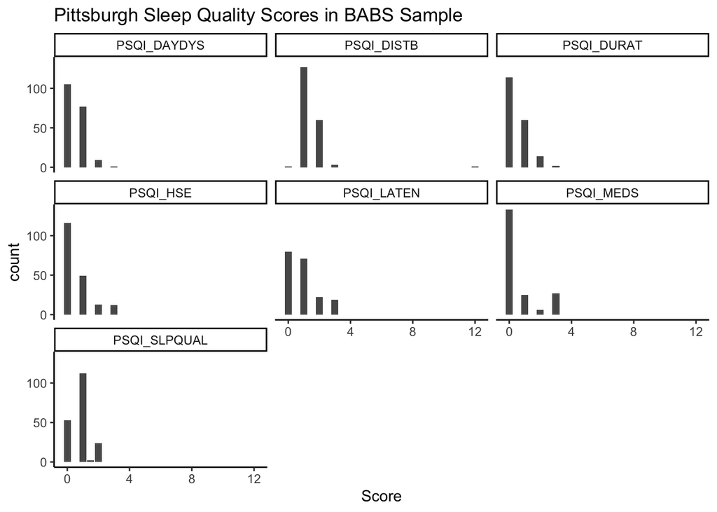

```r
#creating long data frame
d.PSQI.long <- d.PSQI %>%
  pivot_longer(names_to = "Facet", values_to = "Score", -c(BABS_ID, `AGE AT SESSION`))
#plotting distribution of scores**
p.PSQI <- ggplot(d.PSQI.long, aes(Score)) +
  geom_bar() +
  labs(title = "Pittsburgh Sleep Quality Scores in BABS Sample") +
  theme_classic() + facet_wrap(.~ Facet)
p.PSQI
```

### Berkeley Retrospective Sleep Questionnaire (BRSQ)

This instrument has not been scored.

```r
d.BRSQ <- BABS.NP.sess1 %>% select(BABS_ID, `AGE AT SESSION`, BRSQ) %>%
                                          distinct(BABS_ID, .keep_all = T) %>%
  mutate_at(vars(starts_with("BRSQ")), as.numeric)
#counting the number of observations and summarizing mean & SD
BRSQ.sum <- d.BRSQ %>% describe() %>% select(-vars) %>% rownames_to_column(var = "Variable") %>%
  filter(Variable != "BABS_ID*") %>% filter(Variable != "AGE AT SESSION")

kable(BRSQ.sum, col.names = c("Variable","N","Mean","SD","Median","Trimmed Mean","Median Abs. Deviation","Min","Max","Range","Skew","Kurtosis","SE"),
      caption = "Berkeley Sleep Summary Table") %>% kable_styling()
```

Berkeley Sleep Summary Table

| Variable | N | Mean | SD | Median | Trimmed Mean | Median Abs. Deviation | Min | Max | Range | Skew | Kurtosis | SE |
| --- | --- | --- | --- | --- | --- | --- | --- | --- | --- | --- | --- | --- |
| BRSQ | 4 | 15.25 | 1.892969 | 14.5 | 15.25 | 0.7413 | 14 | 18 | 4 | 0.6219464 | -1.79134 | 0.9464847 |

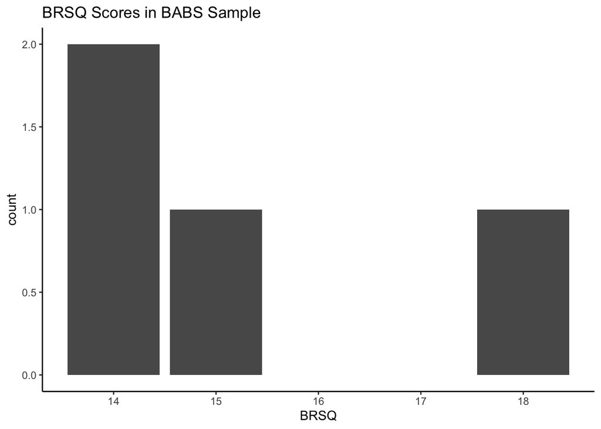

```r
#plotting distribution of scores
p.BRSQ <- ggplot(d.BRSQ, aes(BRSQ)) +
  geom_bar() +
  labs(title = "BRSQ Scores in BABS Sample") +
  theme_classic()
p.BRSQ
```

## Meta-cognition

### Metamemory Questionnaire for Older Adults

Note: Scores should be integers only (General range: 18-90; Ability range: 20-100; Strategy range: 19-95). Table printed below with values not entered as integers.

Following scores are out of range (_GENERAL): BABS112, BABS134, BABS151, BABS132, BABS133, BABS152 Following scores are out of range (_STRATEGIES): BABS152

```r
d.Metamem <- BABS.NP.sess1 %>% select(BABS_ID, `AGE AT SESSION`, starts_with("METAMEMORY")) %>%
                                          distinct(BABS_ID, .keep_all = T) %>%
  mutate_at(vars(starts_with("METAMEMORY")), as.numeric)
#counting the number of observations and summarizing mean & SD
Metamem.sum <- d.Metamem %>% describe() %>% select(-vars) %>% rownames_to_column(var = "Variable") %>%
  filter(Variable != "BABS_ID*") %>% filter(Variable != "AGE AT SESSION")

kable(Metamem.sum, col.names = c("Variable","N","Mean","SD","Median","Trimmed Mean","Median Abs. Deviation","Min","Max","Range","Skew","Kurtosis","SE"),
      caption = "OA Metamemory Summary Table") %>% kable_styling()
```

OA Metamemory Summary Table

| Variable | N | Mean | SD | Median | Trimmed Mean | Median Abs. Deviation | Min | Max | Range | Skew | Kurtosis | SE |
| --- | --- | --- | --- | --- | --- | --- | --- | --- | --- | --- | --- | --- |
| METAMEMORY_GENERAL | 185 | 72.13422 | 26.976921 | 69 | 69.09698 | 11.8608 | 37.00 | 244 | 207.00 | 4.1642398 | 21.1855450 | 1.9833827 |
| METAMEMORY_ABILITY | 185 | 73.87908 | 9.988247 | 74 | 73.98758 | 10.3782 | 46.32 | 98 | 51.68 | -0.0903102 | -0.0460747 | 0.7343505 |
| METAMEMORY_STRATEGIES | 184 | 60.75245 | 11.907653 | 62 | 61.26318 | 10.3782 | 0.00 | 89 | 89.00 | -0.8187070 | 2.7377759 | 0.8778438 |

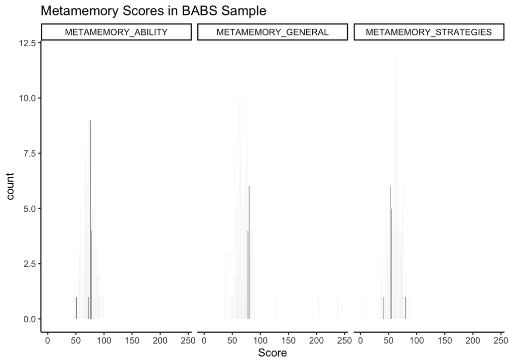

```r
#creating long data frame
d.Metamem.long <- d.Metamem %>%
  pivot_longer(names_to = "Facet", values_to = "Score", -c(BABS_ID, `AGE AT SESSION`))
#plotting distribution of scores
p.metamem <- ggplot(d.Metamem.long, aes(Score)) +
  geom_bar() +
  labs(title = "Metamemory Scores in BABS Sample") +
  theme_classic() + facet_grid(.~ Facet)
p.metamem
```

```r
#flagging non-integer values
flag.metamem <- d.Metamem.long %>% mutate(integ_test = is_wholenumber(d.Metamem.long$Score)) %>%
     filter(integ_test == FALSE)
kable(flag.metamem, caption = "Incorrectly entered (non-integer) values for the Metamemory Questionnaire") %>% kable_styling()
```

Incorrectly entered (non-integer) values for the Metamemory Questionnaire

| BABS_ID | AGE AT SESSION | Facet | Score | integ_test |
| --- | --- | --- | --- | --- |
| BABS008 | 81 | METAMEMORY_GENERAL | 65.65 | FALSE |
| BABS008 | 81 | METAMEMORY_ABILITY | 74.55 | FALSE |
| BABS009 | 77 | METAMEMORY_ABILITY | 94.74 | FALSE |
| BABS012 | 76 | METAMEMORY_GENERAL | 74.12 | FALSE |
| BABS014 | 68 | METAMEMORY_ABILITY | 65.56 | FALSE |
| BABS024 | 74 | METAMEMORY_STRATEGIES | 62.28 | FALSE |
| BABS041 | 72 | METAMEMORY_GENERAL | 71.50 | FALSE |
| BABS042 | 80 | METAMEMORY_ABILITY | 74.44 | FALSE |
| BABS043 | 69 | METAMEMORY_ABILITY | 97.89 | FALSE |
| BABS058 | 68 | METAMEMORY_GENERAL | 59.65 | FALSE |
| BABS069 | 77 | METAMEMORY_STRATEGIES | 71.78 | FALSE |
| BABS074 | 72 | METAMEMORY_GENERAL | 39.88 | FALSE |
| BABS074 | 72 | METAMEMORY_ABILITY | 46.32 | FALSE |
| BABS075 | 68 | METAMEMORY_GENERAL | 52.50 | FALSE |
| BABS075 | 68 | METAMEMORY_ABILITY | 62.35 | FALSE |
| BABS083 | 62 | METAMEMORY_STRATEGIES | 73.89 | FALSE |
| BABS086 | 66 | METAMEMORY_ABILITY | 84.44 | FALSE |
| BABS088 | 66 | METAMEMORY_ABILITY | 73.68 | FALSE |
| BABS089 | 70 | METAMEMORY_ABILITY | 90.53 | FALSE |
| BABS092 | 72 | METAMEMORY_GENERAL | 77.53 | FALSE |
| BABS099 | 82 | METAMEMORY_ABILITY | 75.50 | FALSE |
| BABS099 | 82 | METAMEMORY_STRATEGIES | 41.50 | FALSE |
| BABS100 | 72 | METAMEMORY_ABILITY | 72.63 | FALSE |
| BABS182 | NA | METAMEMORY_ABILITY | 74.50 | FALSE |
| BABS241 | NA | METAMEMORY_ABILITY | 80.50 | FALSE |

### Behavior Rating Inventory of Executive Function-Adult (BRIEF-A)

Note: Scores should be integers only (Total range : 32-224; WM range: 8-56; Initiate range: 8-56; PO range: 10-70; TM range: 6-42). The following values were entered as non-integers: BABS007 (BRIEF_WM = 14.5, BRIEF_TOTAL = 46.5); BABS014 (BRIEF_PO = 20.5, BRIEF_TOTAL = 77.5), BABS171 (BRIEF_TM = 9.5, BRIEF_TOTAL = 42.5).

Following scores are out of range: BABS284(0s are not an acceptable value; multiple subscales), BABS260 (BRIEF_WM = 72, BRIEF_PO = 71, BRIEF_TM = 57, BRIEF_TOTAL = 36), BABS264 (BRIEF_WM = 65, BRIEF_PO = 77, BRIEF_TM = 75, BRIEF_TOTAL = 28), BABS199 (BRIEF_WM = 62, BRIEF_PO = 73, BRIEF_TM = 75, BRIEF_TOTAL = 28).

It appears that in instances when there were no observed rawscore, a scores of 0 was entered for “_TOTAL”; should double-check that the following participants do not have any raw scores and then remove 0s from data frame for “_TOTAL”

The following participants have a “BRIEF_TOTAL” == 0: “BABS010” “BABS022” “BABS070” “BABS107” “BABS120” “BABS165” “BABS168” “BABS174” “BABS175” “BABS176” “BABS177” “BABS178” “BABS179” “BABS180” “BABS181” “BABS182” “BABS183” “BABS184” “BABS185” “BABS186” “BABS187” “BABS188” “BABS189” “BABS190” “BABS191” “BABS192” “BABS193” “BABS194” “BABS195” “BABS196” “BABS197” “BABS198” “BABS200”

```r
d.BRIEF <- BABS.NP.sess1 %>% select(BABS_ID, `AGE AT SESSION`, starts_with("BRIEF")) %>%
                                          distinct(BABS_ID, .keep_all = T) %>%
  mutate_at(vars(starts_with("BRIEF")), as.numeric)
#counting the number of observations and summarizing mean & SD
BRIEF.sum <- d.BRIEF %>% describe() %>% select(-vars) %>% rownames_to_column(var = "Variable") %>%
  filter(Variable != "BABS_ID*") %>% filter(Variable != "AGE AT SESSION")

kable(BRIEF.sum, col.names = c("Variable","N","Mean","SD","Median","Trimmed Mean","Median Abs. Deviation","Min","Max","Range","Skew","Kurtosis","SE"),
      caption = "BRIEF-A Summary Table") %>% kable_styling()
```

BRIEF-A Summary Table

| Variable | N | Mean | SD | Median | Trimmed Mean | Median Abs. Deviation | Min | Max | Range | Skew | Kurtosis | SE |
| --- | --- | --- | --- | --- | --- | --- | --- | --- | --- | --- | --- | --- |
| BRIEF_INITIATE | 144 | 13.50000 | 4.789265 | 12 | 12.87931 | 4.4478 | 8 | 33 | 25 | 1.2357571 | 1.6461524 | 0.3991054 |
| BRIEF_WM | 144 | 15.61458 | 9.104237 | 14 | 14.29741 | 4.4478 | 0 | 72 | 72 | 3.6988593 | 18.2939919 | 0.7586864 |
| BRIEF_PO | 144 | 17.69792 | 10.071461 | 15 | 16.11638 | 5.9304 | 0 | 77 | 77 | 3.6424147 | 17.4882548 | 0.8392884 |
| BRIEF_TM | 144 | 11.46875 | 9.052917 | 10 | 10.22845 | 2.9652 | 0 | 75 | 75 | 5.5347801 | 34.1584191 | 0.7544098 |
| BRIEF_TOTAL | 176 | 44.13920 | 25.925976 | 47 | 44.57042 | 21.4977 | 0 | 107 | 107 | -0.3451873 | -0.4652361 | 1.9542440 |

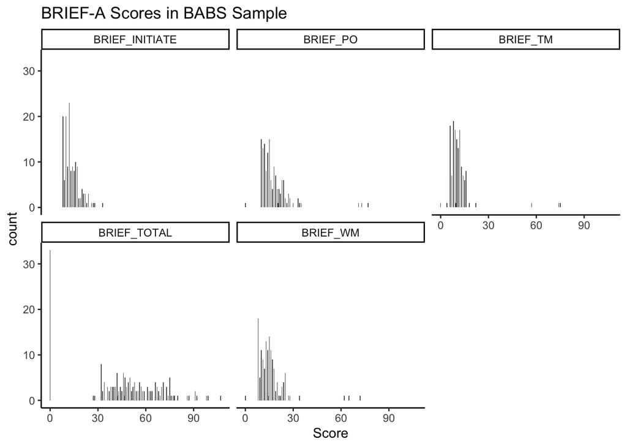

```r
#creating long data frame
d.BRIEF.long <- d.BRIEF %>%
  pivot_longer(names_to = "Facet", values_to = "Score", -c(BABS_ID, `AGE AT SESSION`))
#plotting distribution of scores
p.BRIEF <- ggplot(d.BRIEF.long, aes(Score)) +
  geom_bar() +
  labs(title = "BRIEF-A Scores in BABS Sample") +
  theme_classic() + facet_wrap(.~ Facet)
p.BRIEF
```

## Motivation

### Selection-Optimization-Compensation Questionnaire (SOCQ)

Scores should be integers only (each subscale ranges from 0-12; total= 0-48). There are many instances of non-integer values, so printing a data frame with the incorrect values & subject IDs below.

```r
d.SOCQ <- BABS.NP.sess1 %>% select(BABS_ID, `AGE AT SESSION`, starts_with("SOCQ")) %>%
                                          distinct(BABS_ID, .keep_all = T) %>%
  mutate_at(vars(starts_with("SOCQ")), as.numeric)
#counting the number of observations and summarizing mean & SD
SOCQ.sum <- d.SOCQ %>% describe() %>% select(-vars) %>% rownames_to_column(var = "Variable") %>%
  filter(Variable != "BABS_ID*") %>% filter(Variable != "AGE AT SESSION")

kable(SOCQ.sum, col.names = c("Variable","N","Mean","SD","Median","Trimmed Mean","Median Abs. Deviation","Min","Max","Range","Skew","Kurtosis","SE"),
      caption = "Seletion-Optimization-Compensation Summary Table") %>% kable_styling()
```

Seletion-Optimization-Compensation Summary Table

| Variable | N | Mean | SD | Median | Trimmed Mean | Median Abs. Deviation | Min | Max | Range | Skew | Kurtosis | SE |
| --- | --- | --- | --- | --- | --- | --- | --- | --- | --- | --- | --- | --- |
| SOCQ_ES | 140 | 5.902214 | 2.607229 | 6 | 5.864375 | 2.96520 | 0 | 12 | 12 | 0.0985255 | -0.4328335 | 0.2203511 |
| SOCQ_LBS | 136 | 8.568382 | 2.363343 | 9 | 8.778000 | 2.44629 | 1 | 12 | 11 | -0.7608508 | 0.0853642 | 0.2026550 |
| SOCQ_OPTIMIZATION | 135 | 9.145556 | 2.681492 | 10 | 9.506881 | 1.48260 | 1 | 12 | 11 | -1.1074417 | 0.4873505 | 0.2307861 |
| SOCQ_COMPENSATION | 135 | 8.477259 | 2.890591 | 9 | 8.792202 | 2.96520 | 0 | 12 | 12 | -0.9337512 | 0.2632127 | 0.2487825 |
| SOCQ_TOTAL | 181 | 24.130884 | 15.260506 | 30 | 24.922621 | 11.40119 | 0 | 45 | 45 | -0.6491083 | -1.1418816 | 1.1343044 |

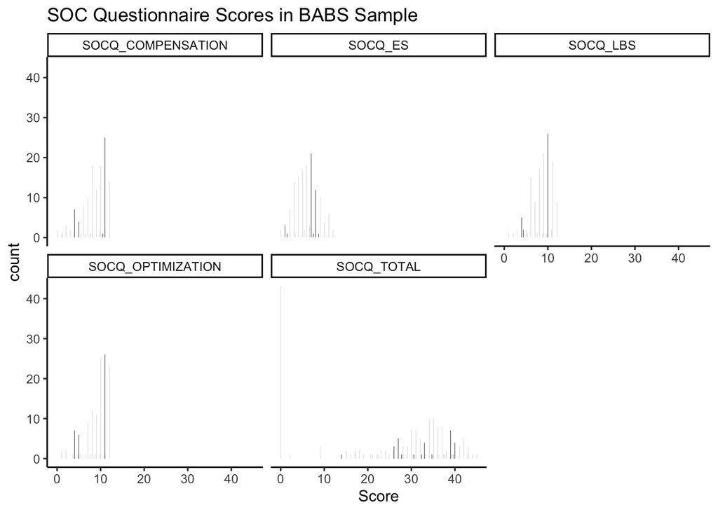

```r
#creating long data frame
d.SOCQ.long <- d.SOCQ %>%
  pivot_longer(names_to = "Facet", values_to = "Score", -c(BABS_ID, `AGE AT SESSION`))
#plotting distribution of scores
p.SOCQ <- ggplot(d.SOCQ.long, aes(Score)) +
  geom_bar() +
  labs(title = "SOC Questionnaire Scores in BABS Sample") +
  theme_classic() + facet_wrap(.~ Facet)
p.SOCQ
```

```r
#flagging values that are incorrect, given the constraints of the scale
flag.socq <- d.SOCQ.long %>% mutate(integ_test = is_wholenumber(d.SOCQ.long$Score)) %>%
  filter(integ_test == FALSE)
kable(flag.socq, caption = "Incorrectly entered values for the SOCQ") %>% kable_styling()
```

Incorrectly entered values for the SOCQ

| BABS_ID | AGE AT SESSION | Facet | Score | integ_test |
| --- | --- | --- | --- | --- |
| BABS007 | 84 | SOCQ_ES | 7.50 | FALSE |
| BABS007 | 84 | SOCQ_OPTIMIZATION | 8.73 | FALSE |
| BABS007 | 84 | SOCQ_COMPENSATION | 10.80 | FALSE |
| BABS007 | 84 | SOCQ_TOTAL | 39.03 | FALSE |
| BABS014 | 68 | SOCQ_LBS | 10.80 | FALSE |
| BABS014 | 68 | SOCQ_COMPENSATION | 1.08 | FALSE |
| BABS014 | 68 | SOCQ_TOTAL | 24.88 | FALSE |
| BABS024 | 74 | SOCQ_ES | 3.27 | FALSE |
| BABS024 | 74 | SOCQ_COMPENSATION | 7.64 | FALSE |
| BABS024 | 74 | SOCQ_TOTAL | 25.91 | FALSE |
| BABS025 | 76 | SOCQ_ES | 6.55 | FALSE |
| BABS025 | 76 | SOCQ_TOTAL | 30.55 | FALSE |
| BABS026 | 78 | SOCQ_ES | 6.55 | FALSE |
| BABS026 | 78 | SOCQ_LBS | 5.33 | FALSE |
| BABS026 | 78 | SOCQ_OPTIMIZATION | 10.91 | FALSE |
| BABS026 | 78 | SOCQ_COMPENSATION | 9.60 | FALSE |
| BABS026 | 78 | SOCQ_TOTAL | 32.39 | FALSE |
| BABS033 | 71 | SOCQ_OPTIMIZATION | 3.60 | FALSE |
| BABS033 | 71 | SOCQ_TOTAL | 20.60 | FALSE |
| BABS041 | 72 | SOCQ_OPTIMIZATION | 7.50 | FALSE |
| BABS041 | 72 | SOCQ_COMPENSATION | 7.50 | FALSE |
| BABS043 | 69 | SOCQ_ES | 5.33 | FALSE |
| BABS043 | 69 | SOCQ_TOTAL | 37.33 | FALSE |
| BABS045 | 75 | SOCQ_ES | 6.55 | FALSE |
| BABS045 | 75 | SOCQ_OPTIMIZATION | 4.80 | FALSE |
| BABS045 | 75 | SOCQ_COMPENSATION | 5.45 | FALSE |
| BABS045 | 75 | SOCQ_TOTAL | 25.80 | FALSE |
| BABS046 | 62 | SOCQ_LBS | 4.36 | FALSE |
| BABS046 | 62 | SOCQ_OPTIMIZATION | 5.45 | FALSE |
| BABS046 | 62 | SOCQ_COMPENSATION | 10.50 | FALSE |
| BABS046 | 62 | SOCQ_TOTAL | 22.31 | FALSE |
| BABS050 | 71 | SOCQ_OPTIMIZATION | 10.80 | FALSE |
| BABS050 | 71 | SOCQ_TOTAL | 25.80 | FALSE |
| BABS057 | 67 | SOCQ_LBS | 4.36 | FALSE |
| BABS057 | 67 | SOCQ_OPTIMIZATION | 9.82 | FALSE |
| BABS057 | 67 | SOCQ_COMPENSATION | 6.55 | FALSE |
| BABS057 | 67 | SOCQ_TOTAL | 27.73 | FALSE |
| BABS058 | 68 | SOCQ_OPTIMIZATION | 10.67 | FALSE |
| BABS058 | 68 | SOCQ_TOTAL | 27.67 | FALSE |
| BABS067 | 63 | SOCQ_LBS | 9.82 | FALSE |
| BABS067 | 63 | SOCQ_COMPENSATION | 10.91 | FALSE |
| BABS067 | 63 | SOCQ_TOTAL | 34.73 | FALSE |
| BABS070 | 73 | SOCQ_ES | 1.50 | FALSE |
| BABS070 | 73 | SOCQ_COMPENSATION | 9.60 | FALSE |
| BABS070 | 73 | SOCQ_TOTAL | 17.10 | FALSE |
| BABS071 | 66 | SOCQ_LBS | 9.60 | FALSE |
| BABS071 | 66 | SOCQ_TOTAL | 39.60 | FALSE |
| BABS074 | 72 | SOCQ_OPTIMIZATION | 10.91 | FALSE |
| BABS074 | 72 | SOCQ_TOTAL | 42.91 | FALSE |
| BABS075 | 68 | SOCQ_ES | 5.33 | FALSE |
| BABS075 | 68 | SOCQ_COMPENSATION | 10.80 | FALSE |
| BABS075 | 68 | SOCQ_TOTAL | 36.13 | FALSE |
| BABS086 | 66 | SOCQ_LBS | 7.50 | FALSE |
| BABS086 | 66 | SOCQ_OPTIMIZATION | 6.55 | FALSE |
| BABS086 | 66 | SOCQ_TOTAL | 28.05 | FALSE |
| BABS092 | 72 | SOCQ_LBS | 8.73 | FALSE |
| BABS092 | 72 | SOCQ_OPTIMIZATION | 10.91 | FALSE |
| BABS092 | 72 | SOCQ_TOTAL | 37.64 | FALSE |
| BABS095 | 75 | SOCQ_ES | 8.73 | FALSE |
| BABS095 | 75 | SOCQ_LBS | 10.80 | FALSE |
| BABS095 | 75 | SOCQ_TOTAL | 39.53 | FALSE |

### BIS/BAS

Note: Ranges for fun-seeking and drive scales are not within the permissible values of the instrument. BABS_072 has a BAS_D score of 110; fun-seeking scores for BABS_012 (31) and BABS_073 (24) are also outside of allowable range.

```r
d.BISBAS <- BABS.NP.sess1 %>% select(BABS_ID, `AGE AT SESSION`, starts_with("BISBAS")) %>%
                                          distinct(BABS_ID, .keep_all = T) %>%
  mutate_at(vars(starts_with("BISBAS")), as.numeric)
#counting the number of observations and summarizing mean & SD
BISBAS.sum <- d.BISBAS %>% describe() %>% select(-vars) %>% rownames_to_column(var = "Variable") %>%
  filter(Variable != "BABS_ID*") %>% filter(Variable != "AGE AT SESSION")

kable(BISBAS.sum, col.names = c("Variable","N","Mean","SD","Median","Trimmed Mean","Median Abs. Deviation","Min","Max","Range","Skew","Kurtosis","SE"),
      caption = "BIS-BAS Summary Table") %>% kable_styling()
```

BIS-BAS Summary Table

| Variable | N | Mean | SD | Median | Trimmed Mean | Median Abs. Deviation | Min | Max | Range | Skew | Kurtosis | SE |
| --- | --- | --- | --- | --- | --- | --- | --- | --- | --- | --- | --- | --- |
| BISBAS_BIS | 140 | 18.86786 | 3.973313 | 19 | 18.88241 | 3.461871 | 9 | 28 | 19 | -0.0908593 | -0.2229031 | 0.3358062 |
| BISBAS_BAS_DRIVE | 140 | 11.29764 | 8.642253 | 11 | 10.63098 | 1.482600 | 4 | 110 | 106 | 10.6245224 | 118.5407917 | 0.7304037 |
| BISBAS_BAS_FUNSEEKING | 140 | 11.01907 | 3.137609 | 11 | 10.91670 | 2.965200 | 5 | 31 | 26 | 2.1163715 | 11.7163637 | 0.2651764 |
| BISBAS_BAS_REWARD | 140 | 16.37500 | 2.825325 | 17 | 16.54911 | 2.965200 | 4 | 24 | 20 | -1.0645580 | 3.5459650 | 0.2387836 |

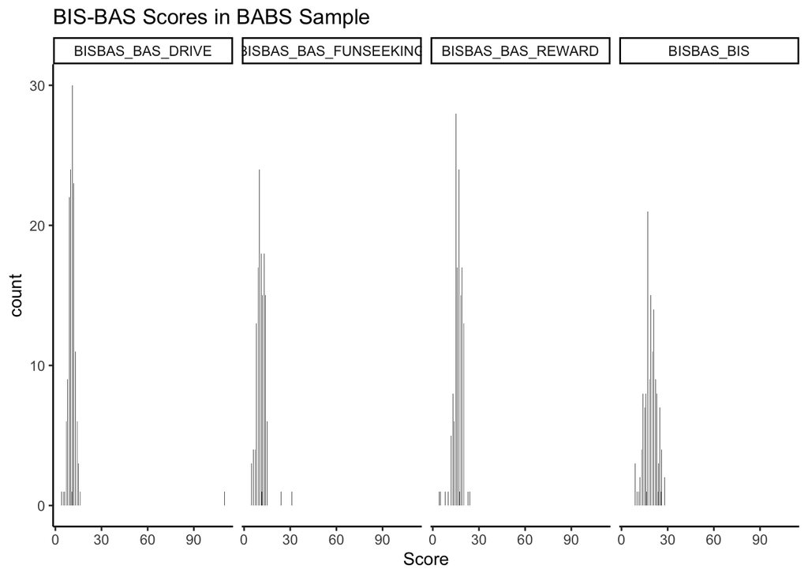

```r
#creating long data frame
d.BISBAS.long <- d.BISBAS %>%
  pivot_longer(names_to = "Facet", values_to = "Score", -c(BABS_ID, `AGE AT SESSION`))
#plotting distribution of scores
p.BISBAS <- ggplot(d.BISBAS.long, aes(Score)) +
  geom_bar() +
  labs(title = "BIS-BAS Scores in BABS Sample") +
  theme_classic() + facet_grid(.~ Facet)
p.BISBAS
```

### Barratt Impulsiveness Scale (BIS-11)

Note: Missing the scoring of the first-order BIS scales.

```r
d.BIS <- BABS.NP.sess1 %>% select(BABS_ID, `AGE AT SESSION`, starts_with("BIS_")) %>%
                                          distinct(BABS_ID, .keep_all = T) %>%
  mutate_at(vars(starts_with("BIS")), as.numeric)
#counting the number of observations and summarizing mean & SD
BIS.sum <- d.BIS %>% describe() %>% select(-vars) %>% rownames_to_column(var = "Variable") %>%
  filter(Variable != "BABS_ID*") %>% filter(Variable != "AGE AT SESSION")

kable(BIS.sum, col.names = c("Variable","N","Mean","SD","Median","Trimmed Mean","Median Abs. Deviation","Min","Max","Range","Skew","Kurtosis","SE"),
      caption = "BIS Summary Table") %>% kable_styling()
```

BIS Summary Table

| Variable | N | Mean | SD | Median | Trimmed Mean | Median Abs. Deviation | Min | Max | Range | Skew | Kurtosis | SE |
| --- | --- | --- | --- | --- | --- | --- | --- | --- | --- | --- | --- | --- |
| BIS_ATTENTION | 178 | 13.85393 | 3.131941 | 14 | 13.66667 | 2.9652 | 8 | 24 | 16 | 0.6150538 | 0.3983614 | 0.2347489 |
| BIS_MOTOR | 179 | 19.58101 | 3.358350 | 19 | 19.39310 | 2.9652 | 10 | 29 | 19 | 0.3975882 | -0.0388380 | 0.2510149 |
| BIS_NONPLANNING | 179 | 19.08939 | 4.010219 | 19 | 18.88276 | 4.4478 | 10 | 34 | 24 | 0.5513031 | 0.6039893 | 0.2997378 |

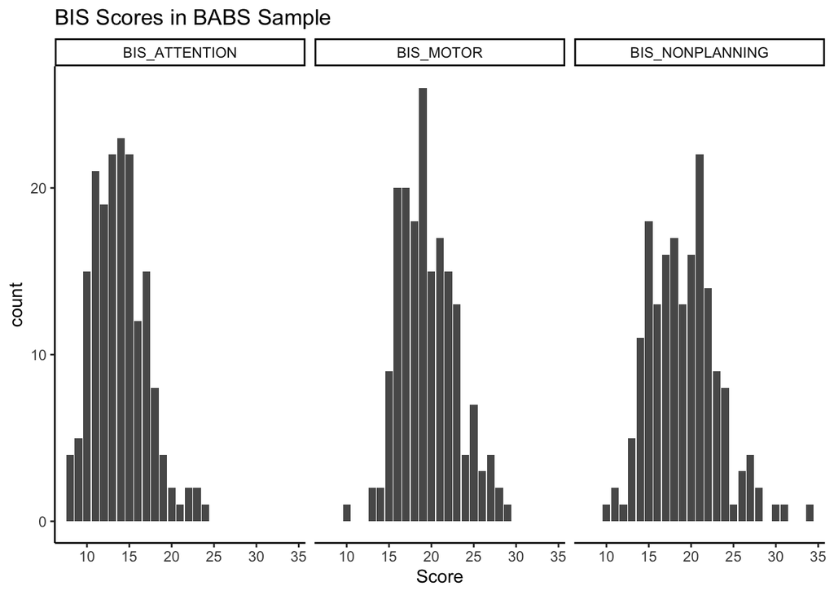

```r
#creating long data frame
d.BIS.long <- d.BIS %>%
  pivot_longer(names_to = "Facet", values_to = "Score", -c(BABS_ID, `AGE AT SESSION`))
#plotting distribution of scores
p.BIS <- ggplot(d.BIS.long, aes(Score)) +
  geom_bar() +
  labs(title = "BIS Scores in BABS Sample") +
  theme_classic() + facet_grid(.~ Facet)
p.BIS
```

### Grit Scale

Note: Range of “GRIT_SCORE” can only range from 1 to 5; it appears that in instances when there was no observed “GRIT_RAW” score, a score of 0 was entered for “GRIT_SCORE”; should double-check that the following participants do not have any Grit scores and then remove 0s from data frame for “GRIT_SCORE”

The following participants have a “GRIT_SCORE” == 0: “BABS118” “BABS120” “BABS121” “BABS174” “BABS175” “BABS176” “BABS177” “BABS178” “BABS179” “BABS180” “BABS181” “BABS182” “BABS183” “BABS184” “BABS185” “BABS186” “BABS187” “BABS188” “BABS189” “BABS190” “BABS191” “BABS192”

```r
d.Grit <- BABS.NP.sess1 %>% select(BABS_ID, `AGE AT SESSION`, starts_with("GRIT")) %>%
                                          distinct(BABS_ID, .keep_all = T) %>%
  mutate_at(vars(starts_with("GRIT")), as.numeric)
#counting the number of observations and summarizing mean & SD
Grit.sum <- d.Grit %>% describe() %>% select(-vars) %>% rownames_to_column(var = "Variable") %>%
  filter(Variable != "BABS_ID*") %>% filter(Variable != "AGE AT SESSION")

kable(Grit.sum, col.names = c("Variable","N","Mean","SD","Median","Trimmed Mean","Median Abs. Deviation","Min","Max","Range","Skew","Kurtosis","SE"),
      caption = "Grit Summary Table") %>% kable_styling()
```

Grit Summary Table

| Variable | N | Mean | SD | Median | Trimmed Mean | Median Abs. Deviation | Min | Max | Range | Skew | Kurtosis | SE |
| --- | --- | --- | --- | --- | --- | --- | --- | --- | --- | --- | --- | --- |
| GRIT_RAW | 138 | 29.557971 | 4.696665 | 30.000 | 29.714286 | 4.4478000 | 19 | 40 | 21 | -0.2372229 | -0.2987075 | 0.3998066 |
| GRIT_SCORE | 160 | 3.186719 | 1.387840 | 3.625 | 3.405273 | 0.6486375 | 0 | 5 | 5 | -1.4695405 | 1.0128597 | 0.1097184 |

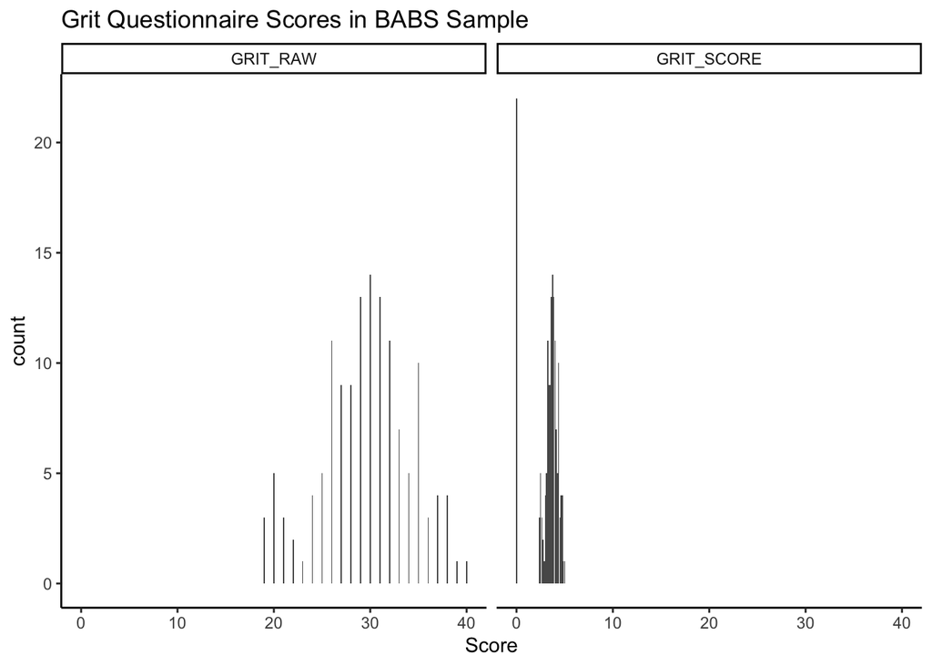

```r
#creating long data frame
d.Grit.long <- d.Grit %>%
  pivot_longer(names_to = "Facet", values_to = "Score", -c(BABS_ID, `AGE AT SESSION`))
#plotting distribution of scores
p.Grit <- ggplot(d.Grit.long, aes(Score)) +
  geom_bar() +
  labs(title = "Grit Questionnaire Scores in BABS Sample") +
  theme_classic() + facet_wrap(.~ Facet)
p.Grit
```

### Zimbardo Time Perspective Scale

Note: It appears that in instances when there was no observed “_RAW” score, a score of 0 was entered for “_SCORE”; should double-check that the following participants do not have any raw scores and then remove 0s from data frame for “_SCORE” variables

The following participants have a “_SCORE” == 0: “BABS010” “BABS082” “BABS107” “BABS120” “BABS121” “BABS124” “BABS127” “BABS153” “BABS163” “BABS165” “BABS167” “BABS168” “BABS169” “BABS170” “BABS172” “BABS174” “BABS175” “BABS176” “BABS177” “BABS178” “BABS179” “BABS180” “BABS181” “BABS182” “BABS183” “BABS184” “BABS185” “BABS186” “BABS187” “BABS188” “BABS189” “BABS190” “BABS191” “BABS192”

```r
d.ZTP <- BABS.NP.sess1 %>% select(BABS_ID, `AGE AT SESSION`, starts_with("ZTP")) %>%
                                          distinct(BABS_ID, .keep_all = T) %>%
  mutate_at(vars(starts_with("ZTP")), as.numeric)
#counting the number of observations and summarizing mean & SD
ZTP.sum <- d.ZTP %>% describe() %>% select(-vars) %>% rownames_to_column(var = "Variable") %>%
  filter(Variable != "BABS_ID*") %>% filter(Variable != "AGE AT SESSION")

kable(ZTP.sum, col.names = c("Variable","N","Mean","SD","Median","Trimmed Mean","Median Abs. Deviation","Min","Max","Range","Skew","Kurtosis","SE"),
      caption = "Zimbardo Time Perspective Summary Table") %>% kable_styling()
```

Zimbardo Time Perspective Summary Table

| Variable | N | Mean | SD | Median | Trimmed Mean | Median Abs. Deviation | Min | Max | Range | Skew | Kurtosis | SE |
| --- | --- | --- | --- | --- | --- | --- | --- | --- | --- | --- | --- | --- |
| ZTPI_PAST_NEGATIVE_RAW | 139 | 25.234547 | 7.4729459 | 25.000000 | 25.070814 | 7.4130000 | 6 | 48.000000 | 42.000000 | 0.2153676 | -0.2954295 | 0.6338470 |
| ZTPI_PAST_NEGATIVE_SCORE | 173 | 2.027516 | 1.2080680 | 2.300000 | 2.061584 | 1.0378200 | 0 | 4.800000 | 4.800000 | -0.4566121 | -0.7238197 | 0.0918477 |
| ZTPI_PRESENT_HEDONISTIC_RAW | 139 | 44.891151 | 8.5748170 | 45.000000 | 45.088230 | 7.4130000 | 5 | 64.000000 | 59.000000 | -0.7001065 | 2.6780573 | 0.7273065 |
| ZTPI_PRESENT_HEDONISTIC_SCORE | 173 | 2.404574 | 1.2979639 | 2.866667 | 2.512811 | 0.6918800 | 0 | 4.266667 | 4.266667 | -1.0125128 | -0.3760217 | 0.0986824 |
| ZTPI_FUTURE_RAW | 139 | 48.117626 | 7.6352946 | 49.000000 | 48.524690 | 5.9304000 | 2 | 63.000000 | 61.000000 | -2.0415385 | 10.1797344 | 0.6476172 |
| ZTPI_FUTURE_SCORE | 173 | 2.973922 | 1.5661026 | 3.615385 | 3.149579 | 0.5702308 | 0 | 4.846154 | 4.846154 | -1.1954073 | -0.2131821 | 0.1190686 |
| ZTPI_PAST_POSITIVE_RAW | 139 | 33.521151 | 5.6323231 | 34.000000 | 33.764956 | 4.4478000 | 8 | 45.000000 | 37.000000 | -0.8241796 | 2.2701992 | 0.4777274 |
| ZTPI_PAST_POSITIVE_SCORE | 173 | 2.992576 | 1.5866684 | 3.666667 | 3.155460 | 0.6589333 | 0 | 5.000000 | 5.000000 | -1.1085792 | -0.2906772 | 0.1206322 |
| ZTPI_PRESENT_FATALISTIC_RAW | 139 | 18.751367 | 5.4082204 | 19.000000 | 18.748407 | 4.4478000 | 2 | 31.000000 | 29.000000 | -0.0915471 | 0.0268025 | 0.4587193 |
| ZTPI_PRESENT_FATALISTIC_SCORE | 173 | 1.674014 | 0.9895266 | 1.888889 | 1.705388 | 0.8236667 | 0 | 3.444444 | 3.444444 | -0.5458924 | -0.7609761 | 0.0752323 |

## Misc

### UCSF Early Developmental History Form

Unscored.